# birtRcpp 入門

用現成的模型分析作答與作答時間：先用 ECM，再用 Gibbs

作者

Jie-Wen Tsai

发布于

2026年10月29日

## 這份教學怎麼讀

**給誰看：** 兩種讀者都可以，從不同的地方開始讀。

- **幾乎沒用過 R、也沒估過 IRT 模型的人：** 從第 0 節「新手導入」開始。它從資料長什麼樣子講起，介紹模型在估什麼、怎麼安裝軟體，最後帶你跑完第一個分析。
- **已經會 R、知道 2PL 的鑑別度與難度是什麼的人**（大學部高年級以上）：可以跳到第 1 節。遇到不熟的詞，查第 0 節最後的查詞表（0.8）。

兩種讀者都不需要會寫 MCMC。

**會學到什麼：** 用 birtRcpp 現成的模型，分析「作答對錯」加上「作答時間」的資料。主線只有四步：

1. 整理資料：`input_data()`；
2. 選模型並估計：例如 `ecm(dat, model = "cross")`；`model =` 是模型的名字；
3. 估計的方法：`ecm()`；
4. 看結果：`summary()` 等。

需要下面三件事的時候，再做第五步：

- 參數的後驗分配：貝氏的結果，詞的意思見 0.8 節查詞表的「Gibbs（貝氏）」表；
- 分位數模型：不看平均的作答時間，改看作答時間偏長（或偏短）的那一端，見第 8 節；
- 作答時間異常檢定：找出作答時間不像模型預期的人，見第 9 節。
5. 從 ECM 的解出發，用 Gibbs 抽樣：`gibbs(dat, model = "cross", init = fit)`。

**為什麼先用 ECM：** `ecm()` 通常幾秒內就算完。它給估計值、標準誤、AIC 與 BIC。大部分的分析，這樣就夠了。

**怎麼讀：**

- 每段程式都很短。
- 程式下面的「逐行說明」解釋每一行在做什麼。
- 「輸出怎麼讀」解釋印出來的東西。
- 標題有「進階」的段落，第一次讀可以跳過。
- 以 `#|` 開頭的行（例如 `#| fig-width: 8`）是這份文件設定圖片大小用的，不是 R 程式。自己寫程式時不用打。

**想自己組模型的人：** 讀完這份之後，看第二份教學《birtRcpp 積木》。積木（`block_model()`）已不建議使用、不再加新功能；一般的分析用這份教學的 `ecm()`／`gibbs()` 就好。

## 0. 新手導入：第一次用 R、第一次做 IRT

這一節給完全的新手。讀完你會知道：資料要整理成什麼樣子、模型在估什麼、怎麼裝好軟體，並且自己跑完第一個分析。已經會 R 與 IRT 的人可以跳到第 1 節。

### 0.1 資料長什麼樣子

一次測驗結束後，每個人在每一題都留下兩筆紀錄：

- **對錯**：答對記 1，答錯記 0；
- **作答時間**：這一題花了幾秒。

整理成表格時，**一列是一個人**，一欄是一題的對錯或秒數。下面是 4 個人、3 題的小例子：

```r
toy <- data.frame(
  id = c("S01", "S02", "S03", "S04"),
  q1 = c(1, 0, 1, 1), q2 = c(0, 0, 1, 1), q3 = c(1, 0, 0, 1),
  q1_sec = c(12.5, 30.2, 8.1, 10.4), q2_sec = c(25.0, 41.3, 15.2, 18.9), q3_sec = c(9.8, 22.4, 12.0, 7.5)
)
toy
```

| id | q1 | q2 | q3 | q1_sec | q2_sec | q3_sec |
| --- | --- | --- | --- | --- | --- | --- |
| S01 | 1 | 0 | 1 | 12.5 | 25.0 | 9.8 |
| S02 | 0 | 0 | 0 | 30.2 | 41.3 | 22.4 |
| S03 | 1 | 1 | 0 | 8.1 | 15.2 | 12.0 |
| S04 | 1 | 1 | 1 | 10.4 | 18.9 | 7.5 |

**逐行說明**

1. `data.frame(...)`：建立一張表。R 把這種表叫**資料框**（data frame）。括號裡每一項是一欄，寫法是「欄名 = 這一欄的值」。
2. `c(1, 0, 1, 1)`：把幾個值串成一串（c 是 combine，合併）。4 個值對應 4 個人。
3. `toy <- ...`：把這張表存起來，取名 `toy`。`<-` 讀作「存成」。後面打 `toy`，就是這張表。
4. 最後一行只打 `toy`：R 把它印出來。

**輸出怎麼讀**

- 最左邊的 1–4 是 R 自動加的列號，不是資料。
- `id`：每個人的代號。
- `q1`–`q3`：三題的對錯。S04 三題全對，S02 三題全錯。
- `q1_sec`–`q3_sec`：三題各花了幾秒。S02 每一題都花最久。

你自己的資料通常存在 Excel 或 CSV 檔裡。只要整理成這個樣子（一列一人、對錯是 0/1、時間是秒），就能用這個套件分析。資料是一列一個「人 × 題」的話，第 11 節會示範怎麼轉。

### 0.2 IRT 的白話說明

**IRT**（item response theory，試題反應理論）是一組統計模型。它把「答對的機率」寫成兩種東西的函數：

- **人的能力**（ability），寫成 θ（讀作 theta）。能力愈高，愈容易答對。
- **題目的特性**：
  - **難度** b（difficulty）：要多少能力，才有一半的機會答對。b 愈大，題目愈難；
  - **鑑別度** a（discrimination）：能力高一點點，答對的機率增加得多快。a 愈大，這一題愈能分出能力的高低。

能力沒有天生的單位。模型把一群人能力的平均定為 0、標準差（SD）定為 1。所以 θ = 1 是「比平均高一個標準差」；b = 1 的題目，對能力在平均的人來說偏難。

只用 a、b 兩個題目參數的模型叫 **2PL**（two-parameter logistic，兩參數邏輯斯模型）。它的式子是：

$$P(\text{答對}) = \frac{1}{1 + \exp(-a(\theta - b))}$$

不用背式子，看圖比較快：

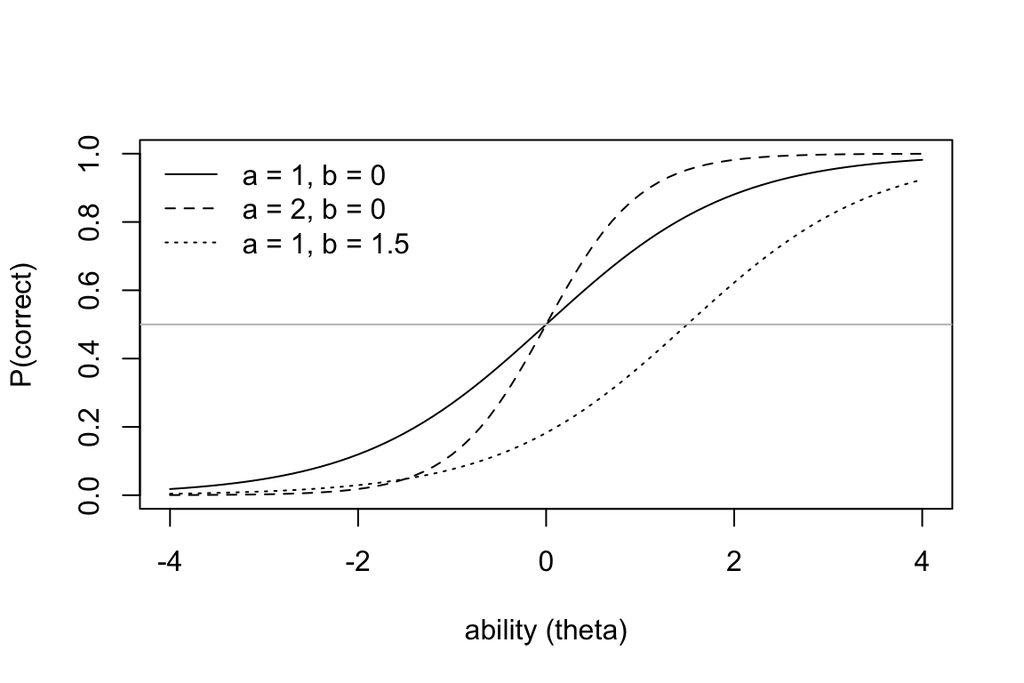

```r
theta <- seq(-4, 4, by = 0.1)
plot(theta, plogis(1 * (theta - 0)), type = "l", ylim = c(0, 1), xlab = "ability (theta)", ylab = "P(correct)")
lines(theta, plogis(2 * (theta - 0)), lty = 2)
lines(theta, plogis(1 * (theta - 1.5)), lty = 3)
abline(h = 0.5, col = "grey")
legend("topleft", c("a = 1, b = 0", "a = 2, b = 0", "a = 1, b = 1.5"), lty = 1:3, bty = "n")
```

**逐行說明**

1. `seq(-4, 4, by = 0.1)`：從 −4 到 4、每次加 0.1 的一串數字，當作能力的範圍，存成 `theta`。
2. `plogis(1 * (theta - 0))`：上面的式子，a = 1、b = 0（`plogis(x)` 就是 1 / (1 + exp(−x))）。`plot(..., type = "l")` 把它畫成一條線；`ylim` 是縱軸的範圍，`xlab`、`ylab` 是兩軸的名字。
3. `lines()`：在同一張圖上再加一條線。這條是 a = 2、b = 0。`lty = 2` 是虛線。
4. 再加一條：a = 1、b = 1.5，點線。
5. `abline(h = 0.5)`：在機率 0.5 的高度畫一條灰色橫線。
6. `legend()`：圖例。`bty = "n"` 是不要外框。

**輸出怎麼讀**

- 這種圖叫**題目特徵曲線**。一條曲線是一題：橫軸是能力，縱軸是答對的機率。
- 曲線穿過灰線（機率 0.5）的位置，就是難度 b。實線和虛線在 θ = 0 穿過；點線在 θ = 1.5 才穿過，所以點線那一題比較難。
- 虛線（a = 2）比實線（a = 1）陡。能力從 −1 走到 1，虛線的答對機率變得比較多：這一題比較能分出能力的高低。

估計一個 IRT 模型，就是從所有人的 0/1 資料，同時找出每一題的 a、b。每個人的能力 θ 也會一起估出來。想多讀一點：de Ayala 的 *The Theory and Practice of Item Response Theory* 裡講 2PL 的那一章。

### 0.3 作答時間：速度與時間強度

只看對錯，會漏掉一些訊息。兩個人都答對了，一個花 10 秒，一個花 60 秒，他們不太一樣。作答時間的模型多了兩種參數：

- **速度** ζ（speed，讀作 zeta）：每個人的作答速度。ζ 愈大，花的時間愈短。
- **時間強度** λ（time intensity，讀作 lambda）：每一題本來要花多少時間。λ 愈大，這一題愈花時間。

模型用的不是秒數，而是秒數的 log（自然對數）：

log 時間 = λ − ζ + 誤差

- 為什麼取 log？秒數一定是正的，而且少數人會花非常久，分配往右拖得很長。取 log 之後，分配比較對稱，比較接近常態分配。
- λ 換回秒數是 e^λ。例如 λ = 4，大約是 e⁴ ≈ 55 秒：能力與速度都在平均的人，在這一題大約花 55 秒。

加上作答時間有三個好處：

- **看出能力與速度的關係**：模型會估計兩者的相關。例如能力高的人是不是也比較快。
- **估得更準**：能力與速度有相關時，作答時間也帶有能力的訊息。
- **找出異常的作答**：時間短得不合理的人，可能在亂猜，或事先看過題目（第 9 節）。

birtRcpp 把對錯的模型（2PL）和時間的模型放在一起估計。這類模型常叫 **RT-IRT**（RT 是 response time，作答時間）。第 2 節會介紹五個現成的模型。

### 0.4 安裝 R、RStudio 與 birtRcpp

要裝三樣東西，每台電腦只要裝一次：

1. **R**：統計軟體本身。到 CRAN（https://cran.r-project.org）下載你的作業系統的版本，照預設安裝。
2. **RStudio**：寫 R 程式用的編輯器，比 R 內建的視窗好用。到 Posit 的網站（https://posit.co/download/rstudio-desktop/）下載免費版。以後打開 RStudio 就好，它會自己啟動 R。
3. **C++ 編譯工具**：birtRcpp 有一部分是用 C++ 寫的，安裝時要先**編譯**（把程式碼轉成電腦能執行的檔案）。
   - Windows：到 CRAN 下載 **Rtools**（https://cran.r-project.org/bin/windows/Rtools/），選和你的 R 版本相同的那一版，照預設安裝。
   - macOS：打開「終端機」（Terminal），輸入 `xcode-select --install`，照畫面的指示安裝 Xcode 命令列工具。

然後在 RStudio 左下角的 **Console**（主控台，打指令的地方）執行下面兩行。這一段只需要做一次，所以這份文件沒有執行它：

```r
install.packages("remotes")
remotes::install_github("jiewenTsai/birtRcpp", build_vignettes = TRUE)
```

**逐行說明**

1. `install.packages("remotes")`：安裝 remotes 套件。**套件**（package）是別人寫好、可以裝進 R 的一組函數。remotes 能從 GitHub 安裝套件。
2. `remotes::install_github(...)`：從 GitHub 下載 birtRcpp 並安裝。`remotes::` 的意思是「用 remotes 套件裡的這個函數」。`build_vignettes = TRUE` 一併安裝英文的簡介（之後用 `vignette("birtRcpp")` 打開）。

**輸出怎麼讀**

- 安裝要幾分鐘，畫面會捲過很多行。最後出現 `* DONE (birtRcpp)` 就是裝好了。
- 出現 `compilation failed`、`make: not found`，或找不到 `g++`、`clang++`：表示第 3 步的編譯工具沒裝好。重裝之後，重開 RStudio 再試一次。

裝好之後，每次打開 RStudio，要先載入套件才能用：`library(birtRcpp)`。

### 0.5 夠用的 R 基本功

這份教學只需要會下面幾件事。

```r
x <- c(3, 5, 10)
mean(x)
```

```
[1] 6
```

```r
toy$q1
```

```
[1] 1 0 1 1
```

```r
nrow(toy)
```

```
[1] 4
```

```r
head(toy, 2)
```

| id | q1 | q2 | q3 | q1_sec | q2_sec | q3_sec |
| --- | --- | --- | --- | --- | --- | --- |
| S01 | 1 | 0 | 1 | 12.5 | 25.0 | 9.8 |
| S02 | 0 | 0 | 0 | 30.2 | 41.3 | 22.4 |

```r
round(mean(toy$q1_sec), digits = 1)
```

```
[1] 15.3
```

**逐行說明**

1. `x <- c(3, 5, 10)`：把三個數字存成 `x`。
2. `mean(x)`：算平均。`mean` 是一個**函數**（function），括號裡放的是給它的**參數**（argument）。
3. `toy$q1`：取出資料框 `toy` 的 `q1` 這一欄。`$` 可以讀作「的」。
4. `nrow(toy)`：資料框有幾列，也就是有幾個人。
5. `head(toy, 2)`：只看前 2 列。資料很大時，用它看一眼就好。
6. `round(..., digits = 1)`：四捨五入到小數 1 位。
   - `digits = 1` 是**有名字的參數**：寫出名字，就不用記參數的順序。
   - 函數裡面可以再放函數。R 從最裡面算起：先取出 `q1_sec`，再算平均，最後四捨五入。

**輸出怎麼讀**

- 每一行前面的 `[1]` 是 R 標的「這一行從第 1 個值開始」，不是資料。
- `mean(x)` 是 6。
- `toy$q1` 是 4 個人第 1 題的對錯。`nrow(toy)` 是 4。
- 最後一行：第 1 題平均花了 15.3 秒。

**還會用到的**

- 查函數怎麼用：在函數名前面加問號，例如 `?ecm`。RStudio 右下角會打開說明頁。
- 讀 CSV 檔：`raw <- read.csv("mydata.csv")`。檔案要放在 RStudio 的**工作資料夾**裡（選單 Session → Set Working Directory），或寫出檔案的完整路徑。
- `#` 後面是**註解**，給人看的說明，R 不會執行。

**看懂錯誤訊息**

程式有錯時，R 會印出 `Error`，然後停下來。先讀冒號後面那一句，它通常會說哪裡錯了。例如欄名打錯：

```r
library(birtRcpp)
input_data(resp = c("q1", "q2", "q4"), data = toy)
```

```
Error: resp: columns not in `data`: q4
```

**逐行說明**

1. `library(birtRcpp)`：載入套件。每次打開 RStudio 都要做一次。
2. `input_data()`：告訴套件哪些欄是作答（下一段會正式用到）。這裡故意寫了一個不存在的欄 `q4`。

**輸出怎麼讀**

- `Error`：出錯了，這一行沒有完成。
- 冒號後面那一句（`columns not in` … `q4`）是說：`resp =` 裡的 `q4` 不在資料框裡。把欄名改成 `q3`，就不會再報錯。
- 載入套件時如果看到 `vi` 被遮蔽（masked）的訊息，那不是錯誤，可以不理它（第 1 節）。
- `Warning`（警告）和 `Error` 不一樣：警告不會停下來，結果還是算出來了，但要讀一下它在提醒什麼。
- 看不懂的錯誤訊息，可以整句複製去網路上搜尋。

### 0.6 第一個完整的分析

下面大約 10 行，從資料到結果。前五行做一份練習用的資料（500 人、10 題）。用自己的資料時，把這五行換成 `raw <- read.csv("mydata.csv")`。

```r
set.seed(1)
cond <- set_cond(n_subj = 500, n_item = 10)
sim <- sim_data(cond, sim_para(cond, "null"), "null")
raw <- data.frame(id = 1:500, sim$Y, round(sim$T, 1))
names(raw) <- c("id", paste0("q", 1:10), paste0("q", 1:10, "_sec"))
head(raw[, c("id", "q1", "q2", "q1_sec", "q2_sec")], 3)
```

| id | q1 | q2 | q1_sec | q2_sec |
| --- | --- | --- | --- | --- |
| 1 | 1 | 1 | 76.3 | 85.1 |
| 2 | 1 | 0 | 96.4 | 27.2 |
| 3 | 0 | 0 | 59.1 | 349.1 |

```r
dat <- input_data(resp = paste0("q", 1:10), time = paste0("q", 1:10, "_sec"), id = "id", data = raw)
fit <- ecm(dat, model = "null")
fit
```

```
model = "null" (rtirt_null)
  500 persons x 10 items
  maximum marginal likelihood (ECM, 41 Gauss-Hermite nodes): 10 iterations, 0.2 s
  logLik -7939.762, npar 42, AIC 15963.524, BIC 16140.537
  Reliability: ability 0.656, speed 0.917
Use summary(), coef(), scores(), estimates(), fit_indices(); gibbs(data, model = ..., init = fit) to sample from here.
```

```r
summary(fit)
```

```
model = "null" (rtirt_null)
  500 persons x 10 items
  maximum marginal likelihood (ECM, 41 Gauss-Hermite nodes): 10 iterations, 0.2 s

$fit  marginal likelihood (persons integrated out)
method     logLik  npar    N        AIC        BIC
ECM     -7939.762    42  500  15963.524  16140.537

$items  item parameters (ECM estimates)
item      a       b  lambda  sigma2t
q1    1.113  -0.250   3.874    0.295
q2    1.267  -0.063   3.929    0.339
q3    0.624  -1.002   3.843    0.340
q4    1.226  -0.576   3.974    0.330
q5    0.915   0.043   4.187    0.321
q6    0.590  -0.337   4.110    0.290
q7    0.872  -0.331   3.960    0.237
q8    0.616  -0.699   4.187    0.339
q9    0.999  -0.418   4.352    0.223
q10   1.325   0.860   3.976    0.374

$se  standard errors of the item parameters
item      a      b  lambda  sigma2t
q1    0.177  0.105   0.035    0.021
q2    0.197  0.093   0.037    0.023
q3    0.136  0.247   0.037    0.023
q4    0.195  0.114   0.036    0.023
q5    0.157  0.115   0.036    0.022
q6    0.131  0.177   0.035    0.020
q7    0.153  0.128   0.034    0.017
q8    0.134  0.207   0.037    0.023
q9    0.166  0.120   0.033    0.016
q10   0.222  0.129   0.038    0.026

$parameters  ML estimate, SE, Wald z and 95% interval (log scale for a, sigma2t, var_speed; Fisher-z for the correlation)

Discrimination (a):
                     Estimate  Std.Err  z-value  P(>|z|)  ci.lower  ci.upper
    q1                  1.113    0.177                       0.815     1.521
    q2                  1.267    0.197                       0.934     1.720
```

[output cut: 41 more lines]

```
    q5                  0.321    0.022                       0.280     0.368
    q6                  0.290    0.020                       0.253     0.333
    q7                  0.237    0.017                       0.206     0.273
    q8                  0.339    0.023                       0.296     0.388
    q9                  0.223    0.016                       0.194     0.257
    q10                 0.374    0.026                       0.327     0.428

Structural:
                     Estimate  Std.Err  z-value  P(>|z|)  ci.lower  ci.upper
    cor_ability_speed   0.241    0.056    4.316   <0.001     0.129     0.347
    var_speed           0.333    0.023                       0.291     0.381

$reliability  reliability of the EAP scores (final E-step)
ability  speed
  0.656  0.917
```

**逐行說明**

1. `set.seed(1)`：固定**亂數種子**。下面的資料是電腦隨機產生的；固定種子，每次執行才會得到一樣的資料。
2. `set_cond()`：設定練習資料的大小，500 人、10 題。
3. `sim_data(...)`：照 `"null"` 這個模型隨機產生資料（`sim_para()` 先產生一組「真的」題目參數）。`sim$Y` 是對錯，`sim$T` 是秒數。
4. `data.frame(...)`：把 ID、對錯和秒數放進同一個資料框，像 0.1 節的 `toy`。`round(sim$T, 1)` 把秒數取到小數 1 位，像碼錶記的時間。
5. `names(raw) <- ...`：替每一欄命名：`id`、`q1`–`q10`（對錯）、`q1_sec`–`q10_sec`（秒數）。`paste0("q", 1:10)` 會做出 “q1”、“q2”、…、“q10” 這 10 個名字。
6. `head(...)`：看前 3 個人的幾個欄位，確定資料長得像 0.1 節那樣。
7. `input_data()`：告訴套件哪些欄是什麼：`resp =` 是對錯的欄、`time =` 是秒數的欄、`id =` 是 ID 的欄、`data =` 是資料框。套件會檢查資料，並把秒數取 log。
8. `ecm(dat, model = "null")`：估計模型。
   - `model = "null"` 是最基本的「對錯 + 時間」模型：每題有 a、b、λ，能力與速度可以有相關；
   - `ecm()` 是估計的方法，找出最能解釋資料的參數值（**最大概似估計**，詳見第 4 節）。通常一兩秒就算完。
9. `fit`：印出簡短的摘要。
10. `summary(fit)`：印出所有的結果表。

**輸出怎麼讀：先看這四個地方**

`summary(fit)` 印了很多表。第一次看，只要找下面四個地方：

1. **每題的難度與鑑別度**（`$items` 表的 `a`、`b` 兩欄）。
   - `b`：q10 最難（0.860），q3 最容易（−1.002）。大多數題目的 b 小於 0，表示這份測驗對這群人偏容易。
   - `a`：q10（1.325）和 q2（1.267）最能分出能力高低；q6（0.590）最差。
2. **每題要花多少時間**（同一張表的 `lambda` 欄）。q9 最花時間：λ = 4.352，換回秒數是 e^4.352 ≈ 78 秒；q3 最快：λ = 3.843，約 47 秒。
3. **能力與速度的相關**（`$parameters` 最後的 `Structural` 段，`cor_ability_speed` 那一列）。
   - 估計值 0.241，95% 區間從 0.129 到 0.347，不含 0；
   - 速度 ζ 愈大表示愈快，所以相關是正的，表示能力高的人通常也作答得比較快一點。
4. **信度**（最後的 `$reliability`，`fit` 的 `Reliability` 那行也有）。
   - 能力 0.656、速度 0.917。信度介於 0 到 1，愈接近 1，表示估出來的分數愈穩定、測量誤差愈小；
   - 速度的信度比較高，因為 10 個連續的秒數，比 10 個 0/1 帶有更多訊息。

其他的欄位：

- 數字都印到小數 3 位。存在 `fit` 裡的值沒有四捨五入。
- `$se` 和 `Std.Err` 是**標準誤**：估計值有多不確定，愈小愈準。
- `ci.lower`、`ci.upper` 是 95% 區間的兩端：參數的真值很可能落在這個範圍裡。
- `P(>|z|)` 是「這個參數等於 0」的 p 值，`<0.001` 表示小於 0.001。
- `logLik`、`AIC`、`BIC` 用來比較模型（第 4 節）。
- `sigma2t`（log 時間的誤差變異數）、`var_speed`（速度的變異數）也會在第 4 節說明。

### 0.7 接下來讀什麼

- 第 1–4 節：同樣的流程，換成交叉關係模型（能力會不會直接影響某一題花的時間），每一個輸出都逐行解釋。
- 第 2 節：五個現成的模型，以及什麼時候用哪一個。
- 第 3 節：資料有問題時會看到的訊息；共變項（例如性別）要先置中。
- 第 11 節：從 CSV 檔到報告（長格式、毫秒、遺漏值）。
- 第 12 節：常見問題。
- 英文的簡短版本：`vignette("birtRcpp")`。

### 0.8 查詞表：先認識幾個詞

下面的詞很多。第一次讀時先瀏覽一遍就好，後面遇到再回來查。

**資料與模型**

| 詞 | 意思 |
| --- | --- |
| 受試者 j、題目 i | j = 1, …, N 是人；i = 1, …, K 是題目。資料矩陣一列一人、一欄一題 |
| 作答 $y_{ij}$ | 受試者 j 在第 i 題答對（1）或答錯（0） |
| 作答時間 $t_{ij}$ | 受試者 j 在第 i 題花了幾秒。模型用的是 log 秒數 |
| 能力 θ（ability） | 每個人的能力，愈大愈容易答對 |
| 速度 ζ（speed） | 每個人的作答速度，愈大花的時間愈短 |
| 鑑別度 a、難度 b | 題目的 2PL 參數 |
| 時間強度 λ | 題目平均要花多少 log 時間（愈大愈花時間） |
| 殘差變異數 σ² | 同一題的 log 時間，扣掉人和題目的效果之後，還剩多少變異（也就是誤差 e 的變異數） |
| 交叉關係 ρ | 能力高的人在這一題花的時間是比較多還是比較少（正負號怎麼讀見第 2 節） |
| 共變項 | 用來解釋能力或速度的「人的變項」，例如性別、年齡（英文 covariate；不是共變異數） |
| 題目參數 | 每一題自己的參數：a、b、λ、σ²、ρ |
| 結構參數 | 描述「一群人」的參數，例如速度的變異數、能力與速度的相關、共變項的迴歸係數 |

**ECM（最大概似）**

| 詞 | 意思 |
| --- | --- |
| 概似（likelihood） | 給定一組參數值，觀察到這份資料的機率。愈大表示參數愈能解釋資料 |
| 邊際概似（marginal likelihood） | 每個人的能力、速度都不知道。所以把它們每一個可能的值都算一次概似，再依能力、速度的分配加權平均。這個動作叫「積分掉」。積分掉之後，只剩題目參數與結構參數要估 |
| 最大概似估計（ML） | 讓邊際概似最大的那組參數值 |
| EM 演算法 | 求最大概似的一種方法（Bock & Aitkin, 1981 把它用在 IRT）。E 步：用目前的參數，算出每個人能力的分配。M 步：用這個分配更新參數。兩步輪流，直到不再變化 |
| ECM | EM 的一種（Meng & Rubin, 1993）。M 步不一次更新所有參數，而是一組一組更新（例如先更新 a、b，再更新 λ、σ²）。每一組都可以用公式直接算出新值，不用反覆搜尋，所以每一步都很快。a、b 要先借助一個技巧才有公式（見第 4 節的進階段） |
| Gauss-Hermite 求積點 | 把「對能力積分」換成「在幾十個點上加權加總」的方法。點（node）愈多愈準，預設 41 個 |
| 標準誤（SE） | 估計值的不確定性。看對數概似在最大值附近有多「尖」：愈尖，估計值愈確定，標準誤愈小。這個彎曲程度叫「觀察訊息」 |
| Wald 95% 區間 | 估計值 ± 1.96 × 標準誤 |
| logLik、AIC、BIC | 對數概似與兩種模型比較指標。AIC、BIC 同時考慮「配適好」和「參數少」，愈小愈好 |
| EAP、PSD | 看過一個人的作答之後，他能力的平均數（EAP）與 SD（PSD）。EAP 是能力的估計值，PSD 是它的不確定性 |
| MAP | 在概似之外再乘上先驗（「先驗」見下一個表），找乘積最大的那一點。小樣本時比較穩定（第 6 節） |

**Gibbs（貝氏）**

| 詞 | 意思 |
| --- | --- |
| 先驗（prior） | 估計前對參數的假設，例如「a 大約在 1 附近」 |
| 後驗（posterior） | 看過資料之後，對參數的了解。報告它的平均數、SD 與 95% 區間 |
| 95% 區間 | 參數有 95% 的後驗機率落在這個範圍裡 |
| MCMC、Gibbs | 從後驗「抽樣」的方法（MCMC 是馬可夫鏈蒙地卡羅，Gibbs 是其中一種）。抽出幾千個參數值，用它們的平均數、SD 描述後驗 |
| 鏈 | 一串抽出來的值。通常跑 3 條，互相比對 |
| burn-in | 鏈剛開始的部分還沒走到後驗，要丟掉 |
| 混合（mixing） | 鏈在後驗裡走動的快慢。混合好，鏈很快就走遍整個後驗 |
| R̂（Rhat） | 幾條鏈是否一致。小於 1.05 才算收斂 |
| ESS | 有效樣本數：這些抽樣值相當於幾個獨立的值。本套件建議至少 400 |

## 1. 載入

```r
library(birtRcpp)
set.seed(2026)
```

**逐行說明**

- `library(birtRcpp)`：載入套件。
- `set.seed(2026)`：固定亂數種子，讓下面的模擬資料每次都一樣。

**輸出怎麼讀：** 沒有輸出。載入時如果看到 `vi` 被遮蔽（masked）的訊息，可以不理它：birtRcpp 也有一個叫 `vi()` 的函數（已不建議使用）。

讀過第 0 節的人已經載入過套件，這裡再執行一次也沒關係；`set.seed(2026)` 讓後面的模擬資料和這份文件一樣。從這一節起，`raw`、`dat`、`fit` 這些名字會重新建立，換成另一份資料。

## 2. 模型在說什麼

birtRcpp 的模型都有兩條式子，一條給作答，一條給作答時間：

$$\text{logit}\,P(y_{ij}=1) = a_i(\theta_j - b_i), \qquad \log t_{ij} = \lambda_i - \zeta_j\;[-\,\rho_i\theta_j] + e_{ij}.$$

**逐句說明**

- 左式就是 2PL。能力 θ 比難度 b 高愈多，答對機率愈高。a 決定上升得多陡。
- 右式：log 時間 = 題目的時間強度 λ，減掉這個人的速度 ζ，再加上誤差 e。
- 方括號 [ ] 不是數學符號。意思是「這一項只有交叉關係模型才有」：能力也會直接影響作答時間。
- 因為式子裡是**減掉** ρθ：
  - ρ < 0 時，θ 愈大，log 時間反而愈大。也就是能力高的人在這題花得比較久（例如比較仔細）；
  - ρ > 0 時相反，能力高的人花得比較短。
- 誤差 e 是常態分配。第 i 題的誤差變異數是 σ²ᵢ（分位數模型例外，見第 8 節）。

**五個現成的模型**

模型的名字寫在 `ecm()` 或 `gibbs()` 的 `model =`，例如 `ecm(dat, model = "cross")`。

| `model =` | 模型 | 什麼時候用 |
| --- | --- | --- |
| `"irt"` | 只有作答；能力對共變項做迴歸 | 沒有作答時間 |
| `"null"` | 能力與速度有相關，沒有共變項（van der Linden, 2007） | 最基本的「作答 + 時間」模型 |
| `"latreg"` | 能力、速度**各自**對共變項做迴歸，兩者之間只有相關 | 想知道性別等變項怎麼影響能力與速度 |
| `"latent"` | **速度**對共變項和**能力**做迴歸（能力被當成預測速度的變項） | 想知道能力高的人是不是比較快 |
| `"cross"` | 每一題都有自己的 ρ（交叉關係）。能力與速度之間不另外估相關，兩者的關係全部由 ρ 表示 | 想知道能力在哪些題目上影響作答時間 |

- 五個模型都可以用 `ecm()` 估計，也都可以用 `gibbs()` 估計。
- `"latent"` 和 `"cross"` 在 `ecm()` 與 `gibbs()` 裡都可以加上 `quantile = 0.9`，變成分位數模型。
- 舊版的寫法 `rtirt_cross(dat)`、`mlirt(dat)` 等還能用，但會出現「已不建議使用」的警告。
- 分位數模型不看「平均的」log 時間，而是看作答時間分配的某個百分位數。例如 0.9 是第 90 百分位數，也就是作答時間偏長的那一端。
- 分位數模型見第 8 節。

## 3. 準備資料：`input_data()`

### 先做一份練習用的資料

真實資料通常是一個資料框：一列一人，有 ID、每題的對錯、每題的秒數。下面先模擬一份長得一樣的資料。

```r
cond <- set_cond(n_subj = 600, n_item = 10)
sim <- sim_data(cond, sim_para(cond, "cross"), "cross")
raw <- data.frame(pid = 5001:5600, sim$Y, sim$T, gender = rbinom(600, 1, 0.5))
names(raw)[2:21] <- c(sprintf("item%02d", 1:10), sprintf("item%02d_sec", 1:10))
head(raw[, c("pid", "item01", "item02", "item01_sec", "item02_sec", "gender")], 3)
```

| pid | item01 | item02 | item01_sec | item02_sec | gender |
| --- | --- | --- | --- | --- | --- |
| 5001 | 1 | 0 | 12.729074 | 15.669677 | 1 |
| 5002 | 0 | 1 | 7.771395 | 4.702435 | 0 |
| 5003 | 0 | 1 | 7.140047 | 16.292557 | 0 |

**逐行說明**

1. `set_cond()`：設定模擬的大小，600 人、10 題。
2. `sim_para(cond, "cross")` 產生一組交叉關係模型的真值。`sim_data()` 用這組真值模擬資料。`sim` 裡有作答 `sim$Y` 和秒數 `sim$T`。
3. `data.frame(...)`：把 ID（`pid`）、作答、秒數和性別放進同一個資料框。`rbinom(600, 1, 0.5)` 隨機抽 600 個 0/1，抽到 0 和 1 的機率各半。
4. 替第 2–21 欄命名。前 10 欄是作答，命名為 item01–item10。後 10 欄是秒數，命名為 item01_sec–item10_sec。`sprintf("item%02d", 1:10)` 的 `%02d` 把數字補成兩位數（1 變成 01）。
5. `head(..., 3)`：看前 3 人的幾個欄位。

**輸出怎麼讀：** 一列一人。item01、item02 是 0/1，item01_sec、item02_sec 是秒數，gender 是 0/1。例如第一個人（pid 5001）答對第 1 題、答錯第 2 題，兩題各花了約 12.7 秒和 15.7 秒。

### 告訴套件哪些欄是什麼

```r
items <- sprintf("item%02d", 1:10)
times <- paste0(items, "_sec")
dat <- input_data(resp = items, time = times, id = "pid", data = raw)
dat
```

```
input_data: 600 persons x 10 items, response times
  items: item01, item02, item03, item04, item05, item06 ...
```

**逐行說明**

1. `items`：作答欄的名字，“item01”、…、“item10”。
2. `times`：秒數欄的名字，在每個題名後面加上 “_sec”。
3. `input_data()`：
   - `resp =` 作答欄；
   - `time =` 秒數欄（套件會自己取 log）；
   - `id =` 受試者 ID 欄；
   - `data =` 資料框。
4. `dat`：印出來看看。

**輸出怎麼讀**

- 第一行：600 人、10 題、有作答時間（`response times`）。
- 第二行：題目名稱。只列前 6 題，後面用 `...` 省略。
- 這些題名會出現在後面所有的表裡。

**其他寫法**

- 已經有矩陣時：`input_data(resp = Y, time = RT)`，不用 `data =`。
- 時間已經取過 log：改用 `log_time =`。
- 有共變項：加上 `cov = c("gender_c", "age_c")`（見下面「共變項要先置中」）。

### 資料有問題時會怎樣

`input_data()` 會檢查常見的錯誤。下面每一行故意犯一個錯：

```r
input_data(resp = items, time = log(raw[times]), data = raw)
```

```
Error: time must be positive seconds; negative values suggest log times: use log_time =
```

```r
input_data(resp = raw[items] + 1)
```

```
Error: resp is coded 1/2; recode it to 0/1 (e.g. resp - 1)
```

```r
raw2 <- raw
raw2$item03[7] <- NA
input_data(resp = items, data = raw2)
```

```
Error: resp has 1 missing values in 1 persons; birtRcpp needs complete data. Drop those persons first, e.g. data[stats::complete.cases(data[c(resp, time)]), ]
```

```r
input_data(resp = items, time = times, cov = "gender", data = raw)
```

```
input_data: 600 persons x 10 items, response times, 1 covariates
  items: item01, item02, item03, item04, item05, item06 ...
  covariates: gender
```

**逐行說明**

1. 把已經取過 log 的時間 `log(raw[times])` 給 `time =`。這裡 `time =` 直接給資料框，不是給欄名。
2. 把作答全部加 1，變成 1/2 編碼。`resp =` 直接給資料框（或矩陣）時，不用寫 `data =`。
3. `raw2 <- raw`：複製一份資料，原來的 `raw` 不會被改到。
4. 把第 7 個人第 3 題設成缺失（`NA`）。
5. 用有缺失的 `raw2` 建立資料。
6. 把沒有置中的 `gender` 當共變項。

### 共變項要先置中

為什麼要置中？

- 能力的量尺沒有天生的原點。模型把能力的平均固定為 0，量尺的位置才確定。
- 所以能力對共變項的迴歸不放截距。
- 沒有截距時，能力的平均 = 迴歸係數 × 共變項的平均。
- 共變項的平均是 0，能力的平均才會是 0。所以共變項要先減掉平均數，這叫「置中」。

```r
raw$gender_c <- raw$gender - mean(raw$gender)
datc <- input_data(resp = items, time = times, cov = "gender_c", id = "pid", data = raw)
```

**逐行說明**

**輸出怎麼讀：** 沒有輸出，也沒有警告。`datc` 第 7 節會用到。

## 4. 第一個分析：用 `ecm()` 估計交叉關係模型

### 估計

```r
fit <- ecm(dat, model = "cross")
fit
```

```
model = "cross" (rtirt_cross)
  600 persons x 10 items
  maximum marginal likelihood (ECM, 41 Gauss-Hermite nodes): 18 iterations, 0.3 s
  logLik -9946.565, npar 51, AIC 19995.130, BIC 20219.374
  Reliability: ability 0.751, speed 0.966
Use summary(), coef(), scores(), estimates(), fit_indices(); gibbs(data, model = ..., init = fit) to sample from here.
```

**逐行說明**

1. `ecm(dat, model = "cross")`：用 ECM 求最大概似估計值。
   - 第一個參數是資料 `dat`；
   - `model = "cross"` 選模型，這裡是交叉關係模型；
   - 其他設定全部用預設值。
2. `fit`：印出摘要。

**輸出怎麼讀**

- 第 1–2 行：模型名稱與資料大小（600 人 × 10 題）。模型名稱照 `ecm()` 的寫法印成 `model = "cross"`，括號裡的 `rtirt_cross` 是結果物件的類別（class）名稱。
- 第 3 行：估計方法。
  - `maximum marginal likelihood`：最大邊際概似。
  - 括號裡的 `ECM` 是用來求它的演算法；41 是 Gauss-Hermite 求積點的個數。
  - 冒號後面：疊代了 18 次，以及花了幾秒。
- 第 4 行：
  - `logLik`：最大的邊際對數概似，這裡是 −9946.565。
  - `npar`：模型的參數個數。這裡是 51：10 題各有 a、b、λ、σ²、ρ 五個參數，再加上速度的變異數。
  - `AIC`、`BIC`：模型比較指標，愈小愈好。只能拿來比較同一份資料的不同模型。
- 第 5 行 `Reliability`：能力與速度的 EAP 信度。
  - 算法是 Var(EAP) / [Var(EAP) + 平均的 PSD²]。介於 0 到 1，讀法和 α 係數一樣，愈大愈好。
  - 這裡能力 0.751、速度 0.966。速度的信度高很多，因為 10 個連續的作答時間，比 10 個 0/1 作答帶有更多資訊。
- 最後一行列出可以用的函數。要從這個解開始 Gibbs 抽樣，寫 `gibbs(dat, model = "cross", init = fit)`（第 5 節）。

### ECM 在做什麼（進階）

不用懂這一段也能用 `ecm()`。想知道它為什麼快、為什麼可靠，再讀。

- **積分：** 每個人的能力 θ 用 Gauss-Hermite 求積點積分。給定能力之後，log 時間是常態，所以速度 ζ 可以**精確地**積分掉，不用求積點。
- **E 步：** 用目前的參數，算出每個人的能力落在每個求積點的機率。
- **CM 步：** 一組一組更新參數（Meng & Rubin, 1993）。
  - 作答的 a、b：logistic 函數沒有公式解。套件用 Pólya-Gamma 變數（Polson, Scott, & Windle, 2013）把它換成一個二次式的下界，二次式就有公式解。
  - 作答時間的 λ、σ²、ρ 與速度的變異數：常態模型，本來就有公式解。
- **每一步都不會讓概似變小：** 所以 logLik 一路上升，最後停在最大值。
- **加速：** 預設用 SQUAREM（Varadhan & Roland, 2008），疊代次數少很多。
- **標準誤：** 估計完之後，算對數概似在最大值附近的彎曲程度（觀察訊息）。EM 架構下怎麼算這個量，見 Louis（1982）。

看一下疊代的過程：

```r
fit$ecm$iterations
```

```
[1] 18
```

```r
fit$ecm$converged
```

```
[1] TRUE
```

```r
round(head(fit$ecm$trace, 5), 2)
```

```
[1] -10241.21  -9951.13  -9949.06  -9948.69  -9948.00
```

**逐行說明**

1. `fit$ecm`：ECM 的所有結果都放在這裡。`iterations` 是疊代次數。
2. `converged`：有沒有收斂。
3. `trace`：每一次疊代之後的 logLik。`head(..., 5)` 只看前 5 個，`round(..., 2)` 取到小數 2 位。

**輸出怎麼讀**

- 第一個輸出是 18：疊代次數，和摘要的第 3 行一樣。
- 第二個輸出 `TRUE` 表示收斂：logLik 的相對變化已經小於門檻（`tol`）。如果是 `FALSE`，把 `max_iter` 加大再跑（見下表）。
- 第三個輸出是前 5 次疊代之後的 logLik：
  - 第 1 次之後是 −10241.21，第 2 次就升到 −9951.13；
  - 之後每次只再升一點點，最後停在 −9946.565（摘要裡的 logLik）；
  - 每一次都比前一次大，符合上面說的「每一步都不會讓概似變小」。

**`ecm()` 的設定**（一般不用改）

直接寫在 `ecm()` 裡的：

| 參數 | 預設 | 意思 |
| --- | --- | --- |
| `model` | （必填） | 模型的名字（第 2 節的表） |
| `itemtype` | `"2pl"` | `"1pl"` 時所有題目的 a 相同 |
| `speed_var` | `"free"` | 速度的變異數要不要估計（第 7 節） |
| `cov` | `NULL` | 用哪些共變項；`NULL` 是資料裡全部的共變項 |
| `se` | `TRUE` | 要不要算標準誤。`FALSE` 比較快 |
| `prior` | `"ml"` | `"ml"` 是最大概似；`"map"` 加上先驗（第 6 節） |
| `priors` | `NULL` | `prior = "map"` 用的先驗，由 `rtirt_priors()` 設定 |

很少改的，放在 `control = ecm_control(...)` 裡：

| 參數 | 預設 | 意思 |
| --- | --- | --- |
| `max_iter` | 1000 | 最多疊代幾次 |
| `tol` | 1e-10 | 收斂門檻：logLik 的相對變化小於它就停 |
| `nodes` | 41 | Gauss-Hermite 求積點個數 |
| `accelerate` | `TRUE` | 要不要用 SQUAREM 加速 |
| `verbose` | `FALSE` | `TRUE` 時每 10 次疊代印一次 logLik |

例如 `ecm(dat, model = "cross", control = ecm_control(max_iter = 5000))`。

### 看結果：`summary()`

```r
s <- summary(fit)
s$items
```

```
item parameters (ECM estimates)
item        a       b  lambda  sigma2t     rho
item01  1.083   0.231   2.194    0.375   0.117
item02  0.898  -0.439   2.656    0.259  -0.217
item03  1.080   0.828   3.073    0.246   0.193
item04  1.022   0.009   3.081    0.339  -0.220
item05  1.079  -0.153   2.337    0.328  -0.440
item06  1.095  -0.768   2.976    0.376  -0.213
item07  1.074  -0.091   2.418    0.296  -0.106
item08  0.701  -0.511   3.372    0.351  -0.095
item09  0.830  -0.064   3.036    0.292  -0.238
item10  1.190   0.131   2.765    0.244  -0.102
```

```r
s$se
```

```
standard errors of the item parameters
item        a      b  lambda  sigma2t    rho
item01  0.143  0.096   0.047    0.025  0.054
item02  0.129  0.118   0.046    0.017  0.053
item03  0.148  0.125   0.046    0.019  0.053
item04  0.137  0.097   0.047    0.022  0.054
item05  0.142  0.095   0.050    0.024  0.055
item06  0.149  0.120   0.048    0.024  0.055
item07  0.141  0.094   0.046    0.019  0.054
item08  0.116  0.148   0.047    0.022  0.054
item09  0.123  0.114   0.047    0.019  0.053
item10  0.152  0.089   0.045    0.016  0.052
```

**逐行說明**

1. `summary(fit)`：算好所有的表，存成 `s`。
2. `s$items`：題目參數表，一列一題。
3. `s$se`：同樣的表，但內容是標準誤。

**輸出怎麼讀（`s$items`）**

- 每一格是最大概似估計值。
- `a`、`b`：每題的鑑別度與難度。
- `lambda`：時間強度，單位是 log 秒。例如 item01 約 2.19。能力和速度都在平均（θ = 0、ζ = 0）的人，在這題大約花 e^2.19 ≈ 9 秒。
- `sigma2t`：log 時間的殘差變異數。
- `rho`：交叉關係。負的表示能力高的人在這題花的時間較長。例如 item05 約 −0.44，是 10 題裡最負的。

**輸出怎麼讀（`s$se`）**

- 每一格是上表同一格的標準誤。
- λ 的標準誤都在 0.05 左右，比 a（0.12–0.15）小很多。600 人的作答時間是連續的，資訊比 0/1 的作答多。

`print()` 可以挑幾張表一起印：

```r
print(s, tables = c("fit", "parameters"))
```

```
model = "cross" (rtirt_cross)
  600 persons x 10 items
  maximum marginal likelihood (ECM, 41 Gauss-Hermite nodes): 18 iterations, 0.3 s

$fit  marginal likelihood (persons integrated out)
method     logLik  npar    N        AIC        BIC
ECM     -9946.565    51  600  19995.130  20219.374

$parameters  ML estimate, SE, Wald z and 95% interval (log scale for a, sigma2t, var_speed; Fisher-z for the correlation)

Discrimination (a):
                    Estimate  Std.Err  z-value  P(>|z|)  ci.lower  ci.upper
    item01             1.083    0.143                       0.837     1.403
    item02             0.898    0.129                       0.677     1.190
    item03             1.080    0.148                       0.825     1.412
    item04             1.022    0.137                       0.786     1.330
    item05             1.079    0.142                       0.834     1.396
    item06             1.095    0.149                       0.839     1.429
    item07             1.074    0.141                       0.831     1.390
    item08             0.701    0.116                       0.507     0.971
    item09             0.830    0.123                       0.620     1.110
    item10             1.190    0.152                       0.927     1.528

Difficulty (b):
                    Estimate  Std.Err  z-value  P(>|z|)  ci.lower  ci.upper
    item01             0.231    0.096    2.403    0.016     0.043     0.419
    item02            -0.439    0.118   -3.722   <0.001    -0.670    -0.208
    item03             0.828    0.125    6.613   <0.001     0.582     1.073
    item04             0.009    0.097    0.091    0.927    -0.182     0.200
    item05            -0.153    0.095   -1.606    0.108    -0.339     0.034
    item06            -0.768    0.120   -6.395   <0.001    -1.003    -0.532
    item07            -0.091    0.094   -0.966    0.334    -0.276     0.094
    item08            -0.511    0.148   -3.443   <0.001    -0.801    -0.220
    item09            -0.064    0.114   -0.564    0.573    -0.287     0.159
    item10             0.131    0.089    1.473    0.141    -0.043     0.305

Time intensity (lambda):
                    Estimate  Std.Err  z-value  P(>|z|)  ci.lower  ci.upper
    item01             2.194    0.047                       2.100     2.287
    item02             2.656    0.046                       2.566     2.747
```

[output cut: 23 more lines]

```
                    Estimate  Std.Err  z-value  P(>|z|)  ci.lower  ci.upper
    item01             0.117    0.054    2.150    0.032     0.010     0.224
    item02            -0.217    0.053   -4.109   <0.001    -0.320    -0.113
    item03             0.193    0.053    3.617   <0.001     0.089     0.298
    item04            -0.220    0.054   -4.074   <0.001    -0.326    -0.114
    item05            -0.440    0.055   -7.965   <0.001    -0.548    -0.332
    item06            -0.213    0.055   -3.878   <0.001    -0.321    -0.105
    item07            -0.106    0.054   -1.971    0.049    -0.211    -0.001
    item08            -0.095    0.054   -1.740    0.082    -0.201     0.012
    item09            -0.238    0.053   -4.475   <0.001    -0.343    -0.134
    item10            -0.102    0.052   -1.946    0.052    -0.204     0.001

Structural:
                    Estimate  Std.Err  z-value  P(>|z|)  ci.lower  ci.upper
    var_speed          0.965    0.058                       0.858     1.085
```

**逐行說明**

- `tables =` 只印你要的表。可以選 `"fit"`、`"items"`、`"se"`、`"parameters"`、`"reliability"`。不寫就全部印。名字打錯（例如 `"item"`）會報錯並提示正確的名字。

**輸出怎麼讀**

- `$fit`：標題 `marginal likelihood (persons integrated out)` 是說「人的參數已經積分掉」。
  - 欄位是估計方法 `method`（ECM）、logLik、參數個數 `npar`、人數 `N`、AIC、BIC。
- `$parameters`：依參數類別分段，例如 Discrimination (a)、Difficulty (b)、Time intensity (lambda)、Residual variance of log RT (sigma2t)、Cross-relation (rho)。
  - `Estimate`：最大概似估計值；`Std.Err`：標準誤。
  - `z-value` = Estimate / Std.Err；`P(>|z|)`：「參數等於 0」的雙尾 p 值。印成 `<0.001` 表示小於 0.001。
  - `ci.lower`、`ci.upper`：Wald 95% 區間。
- `$parameters` 的標題說：a、sigma2t、var_speed 的區間是在 log 尺度上算，再轉回來。所以這些區間不對稱，也不會出現負值。
- 標題裡的 `Fisher-z for the correlation` 是給「相關」用的轉換。這個模型沒有相關，所以用不到。
- 最後的 `Structural` 段是結構參數。這個模型只有一個：速度的變異數 `var_speed`，約 0.965。

### 其他常用的函數

```r
head(estimates(fit, pars = "^rho"), 3)
```

```
# A tibble: 3 x 7
parameter       est     se       z    q025    q975  sig
rho[item01]   0.117  0.054   2.150   0.010   0.224  *
rho[item02]  -0.217  0.053  -4.109  -0.320  -0.113  *
rho[item03]   0.193  0.053   3.617   0.089   0.298  *
```

```r
head(scores(fit), 3)
```

```
# A tibble: 3 x 5
  id  ability  ability_psd   speed  speed_psd
5001    0.849        0.500  -0.122      0.182
5002   -1.161        0.513   0.248      0.182
5003    0.527        0.488  -0.059      0.181
```

```r
reliability(fit)
```

```
ability   speed
  0.751   0.966
```

**逐行說明**

1. `estimates(fit, pars = "^rho")`：參數表。`pars` 用文字樣式挑參數，`"^rho"` 是「名字開頭是 rho」的參數。`head(..., 3)` 只看前 3 列。
2. `scores(fit)`：每個人的能力與速度，附上 ID。
3. `reliability(fit)`：能力與速度的信度。

**輸出怎麼讀**

- `estimates()`：
  - 表格是 tibble（一種資料框）。第一行 `# A tibble: 3 x 7` 是說這張表有 3 列、7 欄；
  - 所有的表都印到小數 3 位，但存的是完整的值：`estimates(fit)$est` 取出來的數字沒有四捨五入；
  - `parameter` 是參數名稱，方括號裡是題名；
  - `est` 估計值、`se` 標準誤、`z` 是 z 值；
  - `q025` 與 `q975` 是 Wald 95% 區間的兩端，也就是 est ± 1.96 × se。名字借自 Gibbs 的 2.5 與 97.5 百分位數（第 5 節）；
  - `sig` 欄的 `*` 表示 95% 區間不含 0，空白表示含 0。前 3 題都有 `*`。`sig` 只用在「等於 0」有意義的參數（b、β、ρ、相關、`b_ability`）；a、λ、σ² 與 `var_speed` 的 `sig` 是 `NA`：a 與變異數一定是正的，它們的區間在 log 尺度上算，永遠不含 0，打星號沒有意義。
- `scores()`：一列一人。
  - `id` 是 `input_data()` 給的 ID；
  - `ability`、`speed` 是 EAP；`ability_psd`、`speed_psd` 是 PSD；
  - 例如 ID 5001：能力約 0.85（PSD 0.50），速度約 −0.12（PSD 0.18）；
  - 速度的 PSD 比能力小很多。這就是速度的信度比較高的原因。
- `reliability()`：能力 0.751、速度 0.966，和 `fit` 摘要裡的 Reliability 相同。

**`pars` 的文字樣式**（正規表示式）只要會這幾個符號：

| 符號 | 意思 | 例子 |
| --- | --- | --- |
| `^` | 開頭是 | `"^rho"`：rho 開頭的參數 |
| `\\|` | 或 | `"beta\\|cor"`：含 beta 或 cor 的參數 |
| `\\[` | 方括號本身 | `"^a\\["`：a[item01]、a[item02]…… |
| `[1-4]` | 1 到 4 其中一個數字 | `"^rho\\[item0[1-4]"`：rho[item01] 到 rho[item04] |

### 模型比較：AIC、BIC 與概似比檢定

交叉關係真的需要嗎？把它和沒有 ρ 的 `"null"` 模型比較。

```r
f0 <- ecm(dat, model = "null")
anova(f0, fit)
```

```
Likelihood ratio tests of ecm() fits (each row against the row above; valid for nested fits)

f0: model = "null" (rtirt_null)
fit: model = "cross" (rtirt_cross)

     npar      logLik        AIC        BIC    Chisq  Df  Pr(>Chisq)
f0     42  -10120.968  20325.936  20510.607
fit    51   -9946.565  19995.130  20219.374  348.806   9      <0.001  ***
---
Signif. codes:  0 '***' 0.001 '**' 0.01 '*' 0.05 '.' 0.1 ' ' 1
```

**逐行說明**

1. 用 ECM 估計 `"null"` 模型：同一份資料，沒有 ρ，但能力與速度可以有相關。
2. `anova(f0, fit)`：和 `lm()` 的 `anova()` 一樣，把兩個模型並排比較。兩個模型必須是同一份資料（作答與作答時間都一樣），否則會報錯。

**輸出怎麼讀**

- 最上面列出每一列是哪個模型（`f0` 是 `model = "null"`，`fit` 是 `model = "cross"`）。表格依參數個數由少到多排列。
- `npar`：參數個數。`null` 少了 10 個 ρ，多了 1 個能力與速度的相關，所以少 9 個參數（42 對 51）。
- `logLik`：對數概似。`cross` 的 logLik 大很多（−9946.565 對 −10120.968）。
- `AIC`、`BIC`：`cross` 的 AIC（19995.130 對 20325.936）、BIC（20219.374 對 20510.607）都比較小。所以交叉關係模型比較好。AIC、BIC 不需要巢套，任何同一份資料的模型都能比。
- `Chisq`、`Df`、`Pr(>Chisq)`：概似比檢定，下面解釋。

**概似比檢定**

- `"null"` 是 `"cross"` 的特例：10 題的 ρ 都相等時，兩個模型一模一樣。
- 為什麼？所有題目共用一個 ρ 時，「速度 + ρ × 能力」可以合成一個新的速度。這個新速度和能力有相關，就是 `"null"` 模型的相關。
- 這種「一個模型是另一個模型加上限制」的關係叫**巢套**（nested）。巢套的兩個模型可以做概似比檢定。
- 這裡檢定的是：「各題的 ρ 都一樣」這個限制成不成立。
- `anova()` 算的是：
  - `Chisq`：概似比統計量 LR = 2 ×（大模型的 logLik − 小模型的 logLik），348.806；
  - `Df`：自由度 = 兩個模型的參數個數差，9；
  - `Pr(>Chisq)`：卡方分配的右尾機率，就是 p 值。`<0.001` 表示 p 值小於 0.001（p 值都印到小數 3 位，更小的就印成 `<0.001`），也就是非常接近 0。後面的 `***` 是顯著性標記（最下面一行 `Signif. codes` 是對照表）。
- 所以「各題的 ρ 都一樣」不成立：能力影響作答時間的方向和大小，題目之間不同。
- `anova()` 只檢查兩個模型是不是同一份資料，不會檢查是不是巢套；不巢套的模型請只看 AIC、BIC。參數比較多、logLik 卻比較小時，`anova()` 會警告。

### 模型寫成式子：`equations()`

```r
equations(fit)
```

```
Measurement:
  logit P(yᵢⱼ = 1) = aᵢ(abilityⱼ − bᵢ)    i ∈ {item01, item02, …, item10}
           log tᵢⱼ = λᵢ − speedⱼ − ρᵢ·abilityⱼ + εᵢⱼ    i ∈ {item01, item02, …, item10}
               εᵢⱼ ∼ N(0, σᵢ²)

Person variables:
  abilityⱼ ∼ N(0, 1)
    speedⱼ ∼ N(0, s)    s = var_speed

Estimation:
  ECM  maximum marginal likelihood; persons integrated out
```

**逐行說明**

- `equations(fit)`：把模型寫成式子。

**輸出怎麼讀**

- `Measurement`：測量模型，就是第 2 節的兩條式子。
  - 下標 i 是題目、j 是人。`i ∈ {item01, …, item10}` 是說 i 可以是 10 題中的任一題。
  - `ability`、`speed` 就是第 2 節的 θ、ζ。
  - 第三行 `εᵢⱼ ∼ N(0, σᵢ²)`：誤差是常態，變異數 σᵢ² 就是表裡的 `sigma2t`。
- `Person variables`：能力與速度的分配。能力是 N(0, 1)。速度的變異數 s 就是 `var_speed`。兩行分開寫，表示這個模型裡能力和速度沒有相關。
- `Estimation`：估計方法，最大邊際概似，人的參數被積分掉。
- `equations(fit, "latex")` 輸出 LaTeX，可以直接貼進論文。

### 跟真值比較（只有模擬資料才能做）

`dat` 和 `sim` 是同一份資料。`sim` 還帶著模擬時用的真值。

```r
rho_true <- attr(sim, "true_para")$rho
rho_ecm <- estimates(fit, pars = "^rho")$est
round(cbind(true = rho_true, ecm = rho_ecm), 3)
```

```
        true    ecm
 [1,]  0.122  0.117
 [2,] -0.174 -0.217
 [3,]  0.233  0.193
 [4,] -0.154 -0.220
 [5,] -0.361 -0.440
 [6,] -0.183 -0.213
 [7,] -0.071 -0.106
 [8,] -0.035 -0.095
 [9,] -0.160 -0.238
[10,] -0.079 -0.102
```

```r
round(c(bias = mean(rho_ecm - rho_true), rmse = sqrt(mean((rho_ecm - rho_true)^2))), 3)
```

```
  bias   rmse
-0.046  0.051
```

**逐行說明**

1. `attr(sim, "true_para")`：取出真值。`$rho` 是 10 題的 ρ。
2. ECM 估計的 ρ。
3. 並排，取到小數 3 位。
4. `bias`：平均偏誤。`rmse`：均方根誤差。一樣取到小數 3 位。

**輸出怎麼讀**

- 第一張表一列一題：`[1,]` 是 item01，`[10,]` 是 item10。
- 每題的估計值和真值差不到 0.1，大約在一到兩個標準誤（約 0.05）以內。
- 但 10 題的估計值都比真值小一點。所以第二個輸出的 `bias` 約 −0.046，和 `rmse`（約 0.051）差不多大。
- 為什麼 10 題會一起偏？
  - 回想上面巢套那段：log 時間裡有「ζ + ρθ」。每一題的 ρ 都加上同一個數 c，等於把每個人的速度換成 ζ + cθ。
  - 交叉關係模型假設速度和能力無關。資料只能靠這個假設，分辨「整組 ρ 加 c」和「速度與能力有一點相關」。這個分辨不太準。
  - 所以 10 題的估計誤差高度相關，常常一起偏向同一邊。
- 這是這一份樣本的抽樣誤差，不是方法有偏誤。第 10 節重複模擬 20 次，平均的 `bias` 就接近 0。

### 求積點夠不夠（進階）

```r
f61 <- ecm(dat, model = "cross", se = FALSE, control = ecm_control(nodes = 61))
logLik(f61) - logLik(fit)
```

```
'log Lik.' 3.101914e-06 (df=51)
```

**逐行說明**

1. 用 61 個求積點重新估計。求積點的個數放在 `ecm_control(nodes = )`。`se = FALSE` 不算標準誤，比較快。
2. 兩次的 logLik 相減。

**輸出怎麼讀**

- 相減的結果還是 logLik 物件，所以印成 `'log Lik.' 數字 (df=51)`。`df=51` 是參數個數，不用管。
- 差距是 3.1e-06，也就是約百萬分之三，幾乎是 0。表示預設的 41 個點已經夠準。

## 5. 同一個模型，用 `gibbs()` 抽樣

### 什麼時候需要 Gibbs

| 想要 | 用 |
| --- | --- |
| 快速得到估計值與標準誤 | `ecm()` |
| AIC、BIC、概似比檢定 | `ecm()` |
| 參數的後驗分配、後驗區間 | `gibbs()` |
| 分位數模型 | `ecm()`（標準誤是 sandwich 標準誤）或 `gibbs()` |
| 作答時間異常檢定 `person_fit()` | `gibbs()` |
| 小樣本，或參數接近邊界（邊界是參數可以取的極端值，例如變異數接近 0；或 a 跑得很大） | `gibbs()`，或 `ecm(prior = "map")` |

### 從 ECM 的解出發

```r
g <- gibbs(dat, model = "cross", init = fit, n_iter = 2000, n_chain = 3, seed = 1)
g
```

```
model = "cross" (rtirt_cross)
  600 persons x 10 items
  3 chains x 2000 iterations (burn-in 1000, thin 1); 5.0 s
  Reliability: ability 0.745, speed 0.962
  Marginal: DIC 19994.783 (pD 50.697), WAIC 19995.756, LOOIC 19996.484
  Warning: only 98.0% of 51 parameters have ESS > 400 and R-hat < 1.05 (max R-hat 1.015, min ESS 396); run longer (n_iter) or see convergence()
Use summary(), coef(), scores(), estimates(), convergence(), fit_indices(), plot().
```

**逐行說明**

- `gibbs(dat, model = "cross", ...)`：和 `ecm()` 一樣，給資料與模型的名字。
  - `init = fit`：每條鏈從 ECM 的估計值與 EAP 附近出發。`fit` 必須是同一份資料、同一個模型的 `ecm()` 結果。起點已經在後驗的中心附近，所以 burn-in 可以短一點。
  - `n_iter = 2000`：每條鏈 2000 次。前一半（1000 次）自動當 burn-in 丟掉；要自己指定，寫 `control = gibbs_control(n_burnin = 500)`。教學裡為了快才設得這麼小。實際分析先用預設（`n_iter = 5000`、`n_chain = 4`，不寫就是），再看 `print(g)` 有沒有收斂的警告：有的話把 `n_iter` 加大（例如 10000），直到警告消失。
  - `n_chain = 3`：跑 3 條鏈，才能算 R̂。
  - `seed = 1`：固定亂數，結果可以重現。
- `g`：印出摘要。

**輸出怎麼讀**

- 在 R 裡直接跑時，會先看到進度訊息（這份文件把它們藏起來了）：
  - 開始時一行 `model = "cross": sampling 3 chains x 2000 iterations, one after the other; chain 1 of 3 ...`，表示已經在跑；
  - 每條鏈跑完一行，例如 `chain 1 of 3 done (3.2 s); about 6 s left`：這條鏈花了幾秒、大約還要多久（鏈是一條接一條跑的，所以用跑完的鏈估計）；
  - 最後一行說正在算 `fit_indices()` 用的邊際概似。
  - 不想看這些訊息：`control = gibbs_control(verbose = FALSE)`。
- 第 3 行 `3 chains x 2000 iterations (burn-in 1000, thin 1)`：鏈的設定與總共花了幾秒。`thin 1` 表示每一次都保留。
- `Reliability`：用後驗算的信度。能力 0.745、速度 0.962，和 ECM 的 0.751、0.966 很接近。
- `Marginal`：三種貝氏的模型比較指標（DIC、WAIC、LOOIC）。
  - 用法和 AIC 一樣，愈小愈好。
  - 這裡 DIC 是 19994.783，和 ECM 的 AIC 19995.130 幾乎一樣。
  - 括號裡的 `pD` 是「有效參數個數」，這裡 50.697，和 `npar` 51 差不多。
- 最後一行列出可以用的函數。
- 如果有參數沒有達到 `convergence()` 的標準（ESS > 400 而且 R̂ < 1.05），或只跑了一條鏈（算不出 R̂），這裡會多一行 `Warning`。這次有一行：51 個參數裡只有 98.0% 過關（下面的 `convergence()` 會列出是哪一個）。教學為了快只跑 2000 次；正式分析把 `n_iter` 加大，警告就會消失。沒有警告，才表示每個參數都過了這個標準。

### 和 ECM 比較

```r
re <- estimates(fit, pars = "^rho")
rg <- estimates(g, pars = "^rho")
round(data.frame(ecm = re$est, se = re$se, gibbs = rg$est, post_sd = rg$sd), 3)
```

| ecm | se | gibbs | post_sd |
| --- | --- | --- | --- |
| 0.117 | 0.054 | 0.120 | 0.056 |
| -0.217 | 0.053 | -0.215 | 0.053 |
| 0.193 | 0.053 | 0.197 | 0.055 |
| -0.220 | 0.054 | -0.219 | 0.054 |
| -0.440 | 0.055 | -0.439 | 0.055 |
| -0.213 | 0.055 | -0.212 | 0.055 |
| -0.106 | 0.054 | -0.104 | 0.053 |
| -0.095 | 0.054 | -0.092 | 0.055 |
| -0.238 | 0.053 | -0.238 | 0.054 |
| -0.102 | 0.052 | -0.100 | 0.052 |

**逐行說明**

1. ECM 的 ρ：估計值 `est` 與標準誤 `se`。
2. Gibbs 的 ρ：後驗平均數 `est` 與後驗 SD `sd`。
3. 並排，取到小數 3 位。

**輸出怎麼讀**

- 一列一題，順序是 item01 到 item10。
- `ecm` 與 `gibbs` 兩欄幾乎一樣，差距在 0.01 以內。
- `se` 與 `post_sd` 也很接近。
- 樣本夠大、先驗很寬時，最大概似估計值與後驗平均數本來就會很接近。

### 後驗區間與收斂

```r
head(estimates(g, pars = "^rho"), 3)
```

```
# A tibble: 3 x 8
parameter       est     sd    q025    q975   rhat   ess  sig
rho[item01]   0.120  0.056   0.011   0.230  1.002  1611  *
rho[item02]  -0.215  0.053  -0.320  -0.109  1.005  1588  *
rho[item03]   0.197  0.055   0.090   0.306  1.007  1329  *
```

```r
convergence(g)
```

```
98.0% of 51 parameters with ESS > 400 and R-hat < 1.05
parameter     rhat   ess
a[item03]    1.015   396
b[item08]    1.013   913
a[item01]    1.010   694
a[item08]    1.009   780
rho[item09]  1.009  1752
```

**逐行說明**

1. Gibbs 的參數表，前 3 列。
2. `convergence(g)`：檢查收斂。

**輸出怎麼讀**

- `estimates()` 的欄位和 ECM 不同：
  - `est` 後驗平均數、`sd` 後驗 SD；
  - `q025` 與 `q975` 是 95% 後驗區間（後驗分配的 2.5 與 97.5 百分位數）；
  - `rhat`、`ess`：每個參數的 R̂ 與 ESS；
  - `sig` 的 `*` 表示 95% 區間不含 0（只用在 b、β、ρ 這類「等於 0」有意義的參數，其他是 `NA`）。
- 前 3 題 ρ 的 R̂ 都接近 1，ESS 都超過 1300。
- `convergence()`：
  - 第一行：51 個參數裡，98.0%（51 個中的 50 個）的 ESS > 400 而且 R̂ < 1.05；
  - 下面列出 R̂ 最大的 5 個參數。R̂ 都小於 1.02；
  - 沒過的那一個是 `a[item03]`：ESS 是 396，略低於 400。要正式報告的話，把 `n_iter` 加大。
- `convergence()` 只能用在 Gibbs 的結果上。ECM 沒有鏈，看 `fit$ecm$converged` 就好。

### 圖

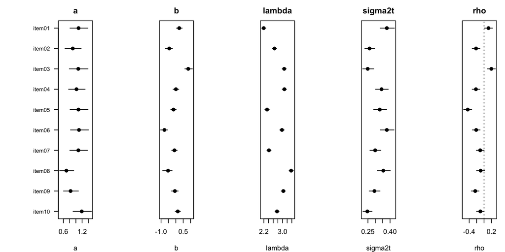

```r
plot(g)
```

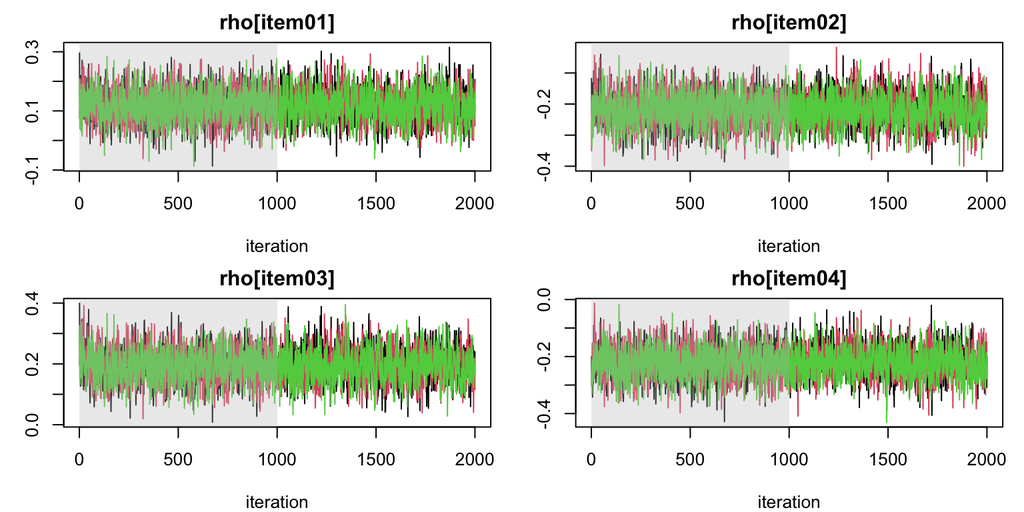

```r
plot(g, "trace", pars = "^rho\\[item0[1-4]")
```

**逐行說明**

1. `plot(g)`：每題參數的後驗平均數與 95% 區間。
2. `plot(g, "trace", ...)`：前 4 題 ρ 的軌跡圖（trace plot）。

**輸出怎麼讀**

- 第一張圖：一個參數類別一格（a、b、lambda、sigma2t、rho），一題一列。點是後驗平均數，橫線是 95% 區間。ρ 那一格的虛線是 0。
- 第二張圖：一個參數一格。
  - 橫軸是第幾次抽樣，縱軸是抽到的值，一種顏色一條鏈；
  - 灰色底的前半段是 burn-in，會被丟掉；
  - 因為從 ECM 的解出發，鏈一開始就在中心附近，看不到「爬上來」的過程。
- 三條鏈應該混在一起、看不出趨勢。如果某一條鏈停在別的位置，就是沒收斂。
- 第一種圖也可以畫 ECM 的結果：`plot(fit)`，橫線是 Wald 95% 區間。軌跡圖只有 Gibbs 才有。
- 結構參數（迴歸係數、能力與速度的相關、速度的變異數）用 `plot(g, "structural")` 畫，ECM 的結果也可以。想用 ggplot2 自己畫，`estimates(g)`（或 `as.data.frame(g)`）就是一個有 `est`、`q025`、`q975` 的資料框。

## 6. 先驗

先驗用在兩個地方：

- `gibbs()` 一定用先驗。
- `ecm(prior = "map")` 用先驗。預設的 `ecm()`（`prior = "ml"`）不用先驗。

**怎麼讀先驗的寫法**

- N(平均數, 變異數)：例如 N(0, 3²) 是平均 0、SD 3 的常態。
- N⁺：只取正值的常態。N⁺(1, 1) 是平均 1、SD 1，只取正值。
- half-t(3, 1)：只取正值、尾巴比常態厚的分配，常用來當 SD 的先驗。3 是自由度，1 是尺度（大約是你猜的 SD 大小）。
- **弱資訊先驗**：很寬的先驗，只排除不合理的值（例如 a = 50），幾乎不影響結果。
- **不依賴資料**：先驗是事先決定的，不是從這份資料算出來的。

**預設的先驗**

| 參數 | 預設 | 意思 |
| --- | --- | --- |
| a | N⁺(1, 1) | 平均 1、SD 1，只取正值 |
| b | N(0, 3²) | 平均 0、SD 3 |
| λ | N(0, 10²) | 平均 0、SD 10，很寬 |
| σ（log 時間的殘差 SD）、速度的 SD | half-t(3, 1) | SD 的弱資訊先驗 |
| 迴歸係數、ρ | N(0, 1) | 平均 0、SD 1 |

### 小樣本：`ecm(prior = "map")`

人少的時候，最大概似的 a 容易跑到很極端的值。`prior = "map"` 把題目參數的先驗加進去，找「概似 × 先驗」最大的那一點。

```r
condSm <- set_cond(n_subj = 120, n_item = 10)
small <- sim_data(condSm, sim_para(condSm, "null"), "null")
a_ml <- estimates(ecm(small, model = "null", se = FALSE), pars = "^a\\[")$est
a_map <- estimates(ecm(small, model = "null", prior = "map", se = FALSE), pars = "^a\\[")$est
a_true <- attr(small, "true_para")$a
round(rbind(true = a_true, ml = a_ml, map = a_map), 2)
```

```
     [,1] [,2] [,3] [,4] [,5] [,6] [,7] [,8] [,9] [,10]
true 1.04 1.01 0.89 0.97 0.93 1.20 1.14 1.11 1.05  1.01
ml   1.23 1.01 0.92 1.58 0.48 0.85 0.99 1.11 0.50  0.96
map  1.23 1.00 0.93 1.46 0.52 0.86 1.00 1.10 0.54  0.95
```

**逐行說明**

1. 設定只有 120 人、10 題。
2. 模擬 `"null"` 模型的資料。
3. 最大概似的 a。`se = FALSE` 不算標準誤，比較快。
4. MAP 的 a。先驗用預設的 N⁺(1, 1)。
5. a 的真值。
6. 三列並排：一欄一題。

**輸出怎麼讀**

- 一欄一題：`[,1]` 是第 1 題，`[,10]` 是第 10 題。
- `ml` 有幾題離真值很遠。例如第 4 題，真值 0.97，最大概似是 1.58；第 5 題和第 9 題，真值約 1，最大概似只有 0.5 左右。
- `map` 把這些極端值拉向先驗的平均 1：第 4 題變成 1.46，第 5 題變成 0.52，第 9 題變成 0.54。
- 本來就不極端的題目，`ml` 和 `map` 幾乎一樣。
- 拉回的幅度不大，因為預設先驗很寬（SD 1）。先驗愈窄，拉得愈多（下一段）。
- `prior = "map"` 只在題目參數（a、b、λ、σ²、ρ）加先驗。結構參數（相關、迴歸係數、速度變異數）仍然是最大概似。

### 改先驗：`rtirt_priors()`

大部分時候用預設就好。要改時，`rtirt_priors()` 裡填的是**平均數和 SD**。同一組先驗可以給 `ecm(prior = "map")`，也可以給 `gibbs()`：

```r
tight <- rtirt_priors(a = c(mean = 1, sd = 0.3), rho = c(sd = 0.1))
fm <- ecm(dat, model = "cross", prior = "map", priors = tight, se = FALSE)
quiet <- gibbs_control(verbose = FALSE, fit_indices = FALSE)
gt <- gibbs(dat,
  model = "cross", init = "ecm", priors = tight,
  n_iter = 2000, n_chain = 3, seed = 1, control = quiet
)
rho_ml <- estimates(fit, pars = "^rho")$est
rho_map <- estimates(fm, pars = "^rho")$est
rho_gibbs <- estimates(gt, pars = "^rho")$est
round(cbind(ml = rho_ml, map_tight = rho_map, gibbs_tight = rho_gibbs), 3)
```

```
          ml map_tight gibbs_tight
 [1,]  0.117     0.185       0.184
 [2,] -0.217    -0.120      -0.121
 [3,]  0.193     0.262       0.263
 [4,] -0.220    -0.121      -0.123
 [5,] -0.440    -0.323      -0.324
 [6,] -0.213    -0.115      -0.116
 [7,] -0.106    -0.016      -0.015
 [8,] -0.095    -0.006      -0.006
 [9,] -0.238    -0.141      -0.140
[10,] -0.102    -0.013      -0.013
```

**逐行說明**

1. `rtirt_priors()`：只寫要改的部分，其他維持預設。這裡把 a 的 SD 改成 0.3，ρ 的 SD 改成 0.1。
2. `ecm(..., prior = "map", priors = tight)`：用新的先驗求 MAP。
3. `gibbs_control()`：很少改的抽樣設定。`verbose = FALSE` 不印進度；`fit_indices = FALSE` 不算模型比較指標，比較快。
4. `gibbs(..., priors = tight)`：用新的先驗抽樣。
   - `init = "ecm"`：不給 ECM 的結果、只寫 `"ecm"` 時，`gibbs()` 會先自己跑一次 ECM（最大概似），再從那裡出發。
5. 取出三種結果的 ρ：第 4 節的最大概似、窄先驗的 MAP、窄先驗的 Gibbs。
6. 並排，取到小數 3 位。

**輸出怎麼讀**

- 一列一題（`[1,]` 是 item01）。三欄是三種結果。
- 窄先驗讓**整組** ρ 一起往上移，每題約移 0.07–0.12。
- 所以 10 題 ρ 的平均被拉向 0：最大概似下約 −0.13，窄先驗下約 −0.04。
- 但不是每一題都靠近 0。原本是正的 item01、item03，反而離 0 更遠。
- 為什麼整組一起動？第 4 節說過，資料很難分辨「整組 ρ 一起加上同一個數」。所以整組的平均，有一部分要靠先驗決定。先驗一變窄，整組就一起被拉向 0。
- `map_tight` 和 `gibbs_tight` 幾乎一樣：同樣的先驗，兩種方法的結論一致。
- 改先驗會改變結果，所以要有理由，並在論文裡寫出來。

## 7. 其他現成模型

### 能力與速度各自對共變項做迴歸：`model = "latreg"`

```r
condJ <- set_cond(n_subj = 800, n_item = 10, n_feat = 2)
dataJ <- sim_data(condJ, sim_para(condJ, "latreg", true_corr = -0.3), "latreg")
ej <- ecm(dataJ, model = "latreg")
estimates(ej, pars = "beta|cor|var_speed")
```

```
# A tibble: 6 x 7
parameter             est     se        z    q025    q975  sig
beta_ability[x1]   -0.067  0.043   -1.550  -0.151   0.018
beta_ability[x2]   -0.149  0.043   -3.464  -0.233  -0.065  *
beta_speed[x1]      0.172  0.020    8.499   0.133   0.212  *
beta_speed[x2]     -0.317  0.020  -15.837  -0.357  -0.278  *
cor_ability_speed  -0.392  0.041   -9.566  -0.469  -0.309  *
var_speed           0.307  0.017            0.275   0.342
```

**逐行說明**

1. 設定 800 人、10 題、2 個共變項（`n_feat = 2`）。
2. 模擬資料。`true_corr = -0.3`：控制共變項之後，能力與速度的真實相關是 −0.3。模擬資料的共變項自動命名為 x1、x2。
3. 用 ECM 估計 `"latreg"` 模型。
4. 只看迴歸係數（`beta`）、相關（`cor`）與速度的變異數（`var_speed`）。`"beta|cor|var_speed"` 的 `|` 是「或」（見第 4 節的符號表）。

**輸出怎麼讀**

- `beta_ability[x1]`、`beta_ability[x2]`：兩個共變項（x1、x2）對能力的效果。
- `beta_speed[x1]`、`beta_speed[x2]`：兩個共變項對速度的效果。
- `cor_ability_speed`：控制共變項之後，能力與速度的相關。
  - 估計值約 −0.39，標準誤 0.04。真值是 −0.3。
  - 差了約 2 個標準誤。這是這一份樣本的抽樣誤差：同樣的設定重複模擬很多次，平均會接近 −0.3（重複模擬的做法見第 10 節）。
- `var_speed`：速度的殘差變異數，約 0.31（模擬時的真值是 0.3）。
- `sig` 欄有 `*` 的，95% 區間不含 0。只有 `beta_ability[x1]` 的區間含 0。`var_speed` 一定是正的，所以 `sig` 是 `NA`。

**概似比檢定：共變項有沒有用**

`"null"` 就是 `"latreg"` 把迴歸係數設成 0 的版本，兩者巢套，可以做概似比檢定（做法同第 4 節）。

```r
e0 <- ecm(dataJ, model = "null")
anova(e0, ej)
```

```
Likelihood ratio tests of ecm() fits (each row against the row above; valid for nested fits)

e0: model = "null" (rtirt_null)
ej: model = "latreg" (rtirt_latreg)

    npar      logLik        AIC        BIC    Chisq  Df  Pr(>Chisq)
e0    42  -13118.533  26321.066  26517.820
ej    46  -12957.103  26006.205  26221.697  322.861   4      <0.001  ***
---
Signif. codes:  0 '***' 0.001 '**' 0.01 '*' 0.05 '.' 0.1 ' ' 1
```

**逐行說明**

1. 同一份資料，估計沒有共變項的 `"null"` 模型。資料裡的共變項，`"null"` 模型不會用到。
2. `anova()`：概似比檢定，和第 4 節一樣。

**輸出怎麼讀**

- `Chisq`：LR 是 322.861。
- `Df`：自由度是 4：能力 2 個、速度 2 個迴歸係數。
- `Pr(>Chisq)`：p 值非常接近 0（`<0.001`）。表示共變項有用。

**用 Gibbs 確認**

```r
gj <- gibbs(dataJ,
  model = "latreg", init = ej, n_iter = 2000, n_chain = 3, seed = 1,
  control = gibbs_control(verbose = FALSE)
)
ce <- estimates(ej, pars = "cor")
cg <- estimates(gj, pars = "cor")
tibble::tibble(method = c("ecm", "gibbs"), estimate = c(ce$est, cg$est), uncertainty = c(ce$se, cg$sd))
```

| method | estimate | uncertainty |
| --- | --- | --- |
| ecm | -0.3919914 | 0.0409773 |
| gibbs | -0.3905271 | 0.0406216 |

**逐行說明**

1. 從 ECM 的解 `ej` 出發抽樣。`gibbs_control(verbose = FALSE)` 不印每條鏈的進度。
2. ECM 的相關：估計值 `est` 與標準誤 `se`。
3. Gibbs 的相關：後驗平均數 `est` 與後驗 SD `sd`。
4. 並排。`uncertainty` 在 ECM 是標準誤，在 Gibbs 是後驗 SD。

**輸出怎麼讀：** 兩種方法幾乎一樣。ECM 是 −0.392（標準誤 0.041），Gibbs 是 −0.391（後驗 SD 0.041）。

### 速度對共變項與能力做迴歸：`model = "latent"`

```r
condL <- set_cond(n_subj = 800, n_item = 10, n_feat = 3)
dataL <- sim_data(condL, sim_para(condL, "latent"), "latent")
el <- ecm(dataL, model = "latent")
estimates(el, pars = "beta|b_ability")
```

```
# A tibble: 4 x 7
parameter     est     se        z    q025    q975  sig
beta[x1]    0.147  0.013   11.165   0.121   0.173  *
beta[x2]    0.168  0.012   13.848   0.144   0.192  *
beta[x3]   -0.401  0.013  -31.597  -0.426  -0.376  *
b_ability  -0.206  0.016  -12.621  -0.238  -0.174  *
```

**逐行說明**

1. 設定 800 人、10 題、3 個共變項。
2. 模擬資料。
3. 用 ECM 估計 `"latent"` 模型。
4. 只看共變項的效果（`beta`）與能力的效果（`b_ability`）。

**輸出怎麼讀**

- 模型是：速度 = `beta[x1]` × x1 + `beta[x2]` × x2 + `beta[x3]` × x3 + `b_ability` × 能力 + 誤差。
- 四個區間都不含 0，所以都有 `*`。
- `b_ability` 約 −0.21（模擬時的真值是 −0.2）。小於 0 表示能力高的人速度較慢（花較多時間）。

### 只有作答：`model = "irt"`

```r
condM <- set_cond(n_subj = 800, n_item = 12, n_feat = 2)
dataM <- sim_data(condM, sim_para(condM, "irt"), "irt")
em_m <- ecm(dataM, model = "irt")
bm <- estimates(em_m, pars = "beta")
tibble::tibble(parameter = bm$parameter, est = bm$est, se = bm$se, true = attr(dataM, "true_para")$beta)
```

| parameter | est | se | true |
| --- | --- | --- | --- |
| beta[x1] | 0.1052757 | 0.0413340 | 0.0643717 |
| beta[x2] | -0.2308451 | 0.0434932 | -0.2085466 |

**逐行說明**

1. 設定 800 人、12 題、2 個共變項。
2. 模擬資料，只有作答。`sim_para()`、`sim_data()` 和 `ecm()` 用同一個名字 `"irt"`（舊的名字 `"mlirt"`，多層次 IRT，也還能用）。
3. 用 ECM 估計 `"irt"` 模型。
4. 取出迴歸係數的參數表。
5. 把估計值、標準誤和真值並排。`attr(dataM, "true_para")` 取出模擬時用的真值。

**輸出怎麼讀**

- 一列一個共變項。`beta[x1]`、`beta[x2]` 是共變項對能力的效果。
- `beta[x1]`：估計 0.105，真值 0.064，差 0.041，約一個標準誤（0.041）。
- `beta[x2]`：估計 −0.231，真值 −0.209，差約半個標準誤。
- 都是正常的抽樣誤差。

### 用自己的資料框加共變項

前面三個例子的資料都是 `sim_data()` 直接模擬的。這一段回到第 3 節自己建的 `datc`，它有置中後的性別。性別是隨機抽的，和能力、速度都無關。

```r
eg <- ecm(datc, model = "latreg")
estimates(eg, pars = "beta")
```

```
# A tibble: 2 x 7
parameter                  est     se       z    q025   q975  sig
beta_ability[gender_c]   0.011  0.101   0.109  -0.186  0.208
beta_speed[gender_c]    -0.032  0.082  -0.386  -0.193  0.129
```

**逐行說明**

1. 用 ECM 估計 `"latreg"` 模型，共變項是 `gender_c`。
2. 只看性別的兩個迴歸係數。

**輸出怎麼讀**

- 參數名稱方括號裡是共變項的名字 `gender_c`。
- 性別對能力的效果約 0.011（標準誤 0.10），對速度的效果約 −0.032（標準誤 0.08）。
- 兩個係數都接近 0，區間都含 0，所以沒有 `*`。這符合資料的模擬方式。

### 速度的變異數要不要固定（進階）

- 預設 `speed_var = "free"`：估計速度的變異數。
- `ecm(dat, model = "cross", speed_var = "fixed")`：把它固定為 1。

用真實資料時請用預設。log 秒數的速度變異數通常遠小於 1（例如 TIMSS 約 0.1），固定成 1 會讓模型配適變差很多。

## 8. 分位數模型（進階）

`quantile = 0.9` 不是看「平均的」作答時間，而是看作答時間分配的第 90 百分位數，也就是「作答時間偏長的那一端」。

- 計算上借用 **ALD**（非對稱拉普拉斯分配）當概似。用它估出來的，就是指定的分位數。
- ALD 只是計算工具，不代表我們相信誤差真的長這樣。所以它叫**工作概似**（working likelihood）。
- `ecm()` 估分位數模型時，標準誤用 **sandwich 標準誤**。一般的標準誤假設概似是對的；ALD 不是資料真正的分配，所以要用 sandwich 標準誤，它把每個人實際的變異也算進去。

```r
fit_q <- ecm(sim, model = "cross", quantile = 0.9)
fit_q
```

```
model = "cross", quantile = 0.9 (rtirt_cross)
  600 persons x 10 items
  maximum marginal ALD working likelihood (ECM, 41 Gauss-Hermite nodes): 21 iterations, 15.9 s
  working logLik -10981.235, npar 51, AIC 22064.469, BIC 22288.713 (compare only fits at the same quantile)
  Standard errors: sandwich (robust to the ALD being a working likelihood)
  Reliability: ability 0.792, speed 0.971
Use summary(), coef(), scores(), estimates(), fit_indices(); gibbs(data, model = ..., init = fit) to sample from here.
```

```r
estimates(fit_q, pars = "^rho")
```

```
# A tibble: 10 x 7
parameter       est     se       z    q025    q975  sig
rho[item01]   0.257  0.056   4.583   0.147   0.367  *
rho[item02]  -0.179  0.075  -2.372  -0.327  -0.031  *
rho[item03]   0.299  0.054   5.564   0.194   0.404  *
rho[item04]  -0.251  0.070  -3.568  -0.390  -0.113  *
rho[item05]  -0.497  0.065  -7.607  -0.625  -0.369  *
rho[item06]  -0.305  0.121  -2.527  -0.542  -0.068  *
rho[item07]  -0.114  0.086  -1.319  -0.283   0.055
rho[item08]  -0.099  0.076  -1.301  -0.249   0.050
rho[item09]  -0.361  0.069  -5.231  -0.496  -0.225  *
rho[item10]  -0.075  0.075  -1.010  -0.221   0.071
```

**逐行說明**

1. 用 ECM 估第 90 百分位數的交叉關係模型。
   - 這一節直接把 `sim` 交給 `ecm()` 與 `gibbs()`，不用 `dat`。`sim_data()` 產生的 `sim` 本身就是一份 `input_data()` 格式的資料，作答和時間都和 `dat` 一樣。
2. 印出結果。
3. 只看 ρ 的估計值（`pars = "^rho"`：名稱以 rho 開頭的參數）。

**輸出怎麼讀**

- 第 3 行 `maximum marginal ALD working likelihood`：估的是 ALD 工作概似的最大值，ECM 跑了 21 次就收斂。
- 第 4 行 `working logLik`、AIC、BIC：都是工作概似算的，只能和**同一個分位數**的其他模型比，不能和平均數模型比。`anova()` 也不接受分位數模型。
- 第 5 行：標準誤是 sandwich 標準誤。
- ρ 的表和第 4 節 ECM 的表一樣讀：`est` 是估計值，`se` 是 sandwich 標準誤，`q025`、`q975` 是 Wald 95% 區間。
- 和平均數模型比，第 90 百分位數的 ρ 大多離 0 更遠，例如 item09 是 −0.361，平均數模型是 −0.238，真值是 −0.160。下面用 Gibbs 估三個分位數時也看得到，原因寫在本節最後的「解讀時要小心」。

```r
qs <- gibbs(sim,
  model = "cross", quantile = c(0.1, 0.5, 0.9), n_iter = 2000, n_chain = 3,
  seed = 2, control = gibbs_control(verbose = FALSE)
)
coefs <- coef(qs)
rho_q <- coefs[grepl("^rho", rownames(coefs)), ]
round(cbind(true = rho_true, ecm_mean = rho_ecm, rho_q), 3)
```

```
              true ecm_mean  q=0.1  q=0.5  q=0.9
rho[item01]  0.122    0.117  0.220  0.128  0.264
rho[item02] -0.174   -0.217 -0.265 -0.232 -0.176
rho[item03]  0.233    0.193  0.267  0.215  0.304
rho[item04] -0.154   -0.220 -0.240 -0.206 -0.256
rho[item05] -0.361   -0.440 -0.488 -0.466 -0.512
rho[item06] -0.183   -0.213 -0.284 -0.204 -0.311
rho[item07] -0.071   -0.106 -0.087 -0.105 -0.117
rho[item08] -0.035   -0.095  0.072 -0.103 -0.096
rho[item09] -0.160   -0.238 -0.263 -0.262 -0.349
rho[item10] -0.079   -0.102  0.017 -0.114 -0.080
```

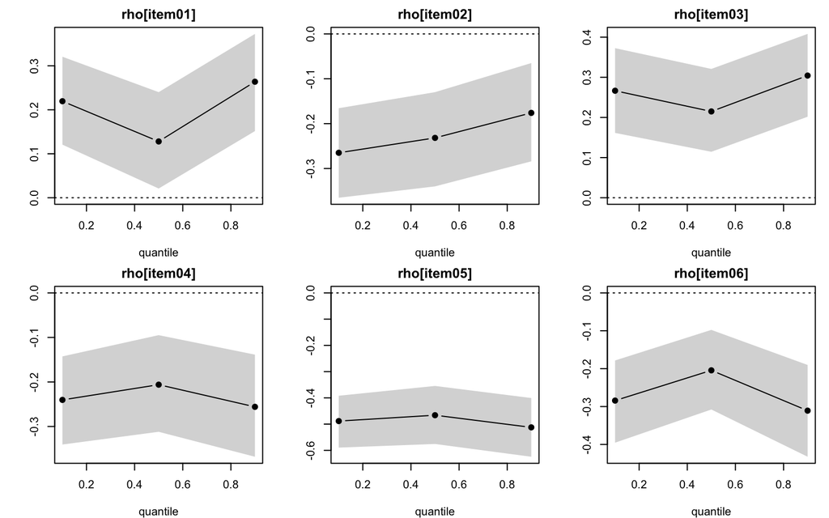

```r
plot(qs, pars = "^rho\\[item0[1-6]\\]")
```

**逐行說明**

1. 給三個分位數，`gibbs()` 會一次估三個模型。這裡沒有寫 `init`，每條鏈從隨機的起點出發；寫 `init = "ecm"` 會先對每個分位數各跑一次 ECM，從那裡出發。
2. `coef(qs)` 是一個矩陣，一列一個參數、一欄一個分位數。
3. 挑出 ρ 的估計值：
   - `rownames()` 取出列名，也就是參數名稱；
   - `grepl("^rho", ...)` 對每個名稱回答「是不是 rho 開頭」（TRUE/FALSE）；
   - `[TRUE 的列, ]` 只留下 ρ 的列，欄全部保留。
4. 把 ρ 的真值、平均數模型的 ECM 估計值（第 4 節的 `rho_true`、`rho_ecm`）和三個分位數模型並排。
5. 畫前 6 題的 ρ 在三個分位數下的估計值。

**輸出怎麼讀**

- 表：一列一題，列名是參數名稱。
  - `true`、`ecm_mean`：第 4 節的真值與 ECM 估計值；
  - `q=0.1`、`q=0.5`、`q=0.9`：三個分位數模型的 ρ（後驗平均數）。
- `q=0.5`（中位數）和 `ecm_mean` 很接近，10 題的差距都在 0.03 以內。
- 圖：一題一格。橫軸是分位數，點是估計值（用線連起來），灰色帶是 95% 區間，虛線是 0。

**解讀時要小心**

- 這份資料的誤差是常態的，所以真正的 ρ 在每個分位數都一樣。
- 但 q = .1 和 .9 時，大多數題目的 ρ 絕對值比真值大。
- q = .1 時，item08 和 item10 的 ρ 甚至變成正的（真值是負的）。
- 這是方法本身的限制，樣本再大也不會消失。它不是抽樣誤差。
- 所以分位數的結果要和平均數模型一起報告，不要單獨解讀。

## 9. 檢定（進階）

### 題目參數會不會隨某個變項改變：`score_test()`

**幾個詞**

- **DIF**（差異試題功能）：能力相同的人，因為組別不同，答對這題的機率卻不同。
- **調節變項**：你懷疑會讓題目參數改變的變項，例如性別。
- **score 檢定**（Merkle & Zeileis, 2013）：只要估一次模型（不必每組各估一次），就能檢定「如果讓題目參數隨這個變項改變，模型會不會明顯變好」。它用的是最大概似估計值，所以直接用 ECM 的結果。
- **Holm 校正**：一次檢定很多題時，把 p 值調大，避免只是碰巧顯著。

```r
total_logtime <- rowSums(dat$log_t)
print(score_test(fit, total_logtime, by_item = TRUE))
```

```
the moderator correlates 0.15 with the ability EAPs: differences in mean ability (impact) show up as shifts of every b; to test DIF beyond impact, put the moderator in the latent regression (e.g. ecm(input_data(..., cov = z), model = "latreg"), z centred) and test that fit
```

```
Score-based test of parameter invariance (DM test, numeric moderator, block decorrelation)
parameters   n  statistic  p.value  p.holm
accuracy    20      1.591    0.225
item01       2      1.569    0.029   0.288
item02       2      1.329    0.114   0.910
item03       2      1.247    0.171   1.000
item04       2      0.814    0.772   1.000
item05       2      0.802    0.790   1.000
item06       2      1.096    0.329   1.000
item07       2      0.761    0.847   1.000
item08       2      1.529    0.037   0.332
item09       2      0.788    0.809   1.000
item10       2      0.764    0.843   1.000
```

```r
set.seed(3)
print(score_test(fit, rbinom(nrow(dat$Y), 1, 0.5) == 1))
```

```
Score-based test of parameter invariance (LM test, factor with 2 levels moderator, block decorrelation)
parameters   n  statistic  p.value
accuracy    20     18.250    0.571
```

**逐行說明**

1. 每人 log 秒數的總和，代表整體作答快慢。`dat$log_t` 是 `input_data()` 存的 log 時間矩陣（一列一人），`rowSums()` 把每一列加總。
2. 用第 4 節的 ECM 結果 `fit`，檢定題目參數是否隨作答快慢改變。
   - `by_item = TRUE`：除了全部題目一起檢定，也逐題檢定。
   - 外面的 `print()` 讓表格照套件的格式印，連標題一起。
3. `set.seed(3)`：固定亂數，讓下一行的隨機分組每次都一樣。
4. 用一個隨機分組檢定，應該不顯著。
   - `dat$Y` 是作答矩陣，`nrow(dat$Y)` 是人數（600）。
   - `rbinom(600, 1, 0.5) == 1` 隨機抽 0/1，再轉成 TRUE/FALSE，當成兩組。
   - 調節變項可以是連續變項，也可以是分組（TRUE/FALSE 或 factor）。

**輸出怎麼讀**

- 第一段開頭的提醒：調節變項和能力的 EAP 相關 0.15。
  - 提醒裡的 impact 是說：調節變項不同的人，平均能力本來就不同。這不是 DIF。
  - 原因與做法見下面的「注意」。
- 標題 `Score-based test of parameter invariance`：檢定題目參數是不是不變。
  - 括號裡的 `DM`、`LM` 是檢定統計量的種類。連續的調節變項用 DM，分組用 LM，函數自動選。
  - `block decorrelation` 是計算方式的預設設定，不用改。
- 表格欄位：
  - `parameters`：檢定的參數。`accuracy` 是全部題目的 a、b 一起檢定；`item01` 等是單題；
  - `n`：檢定的參數個數。全部題目是 20 個，單題是 a、b 兩個；
  - `statistic`：檢定統計量；`p.value`：p 值；
  - `p.holm`：Holm 校正後的 p 值，逐題的結論看這一欄。`accuracy` 那一列只有一個檢定，不用校正，所以是空的。
- 第一段：
  - 全部題目一起：p = .22，不顯著；
  - item01 未校正的 p 是 .029，小於 .05；但 Holm 校正後是 .288。一次檢定 10 題，常會有一兩題碰巧小於 .05，校正就是為了這個；
  - 沒有任何一題的 `p.holm` 小於 .05。
- 第二段：隨機分組，p = .571，不顯著，符合預期。

**注意：** 如果調節變項和能力有關（例如數學自信），能力的差異會讓所有題目看起來都在變。這時要把它放進 `"latreg"` 模型的共變項再檢定。函數發現這種情況會提醒，就是第一段開頭那幾行。

### 作答時間異常的人：`person_fit()`

這個檢定需要後驗抽樣，所以用第 5 節的 Gibbs 結果 `g`。

```r
pf <- person_fit(g)
head(pf, 3)
```

```
# A data frame: 3 x 5
  id      lt  df  p_flag  flagged
5001  11.938  10   0.012  FALSE
5002   7.100  10   0.000  FALSE
5003   7.490  10   0.000  FALSE
```

```r
round(attr(pf, "share"), 3)
```

```
[1] 0.013
```

**逐行說明**

1. `person_fit(g)`：每個人的作答時間適配統計量 $l^t$（Marianti et al., 2014）。
2. 看前 3 人。
3. 被判為不適配的比例，取到小數 3 位。

**輸出怎麼讀**

- 每人一列：
  - `id`：受試者 ID；
  - `lt`：統計量的後驗平均數。模型成立時，它大約是自由度 10（題數）的卡方分配，平均約 10。愈大，表示這個人的作答時間愈不像模型預期；
  - `df`：自由度（題數）；
  - `p_flag`：「這個人不適配」的後驗機率，也就是 lt 超過卡方分配 95 百分位數（自由度 10 時約 18.3）的機率；
  - `flagged`：`p_flag` ≥ .95，也就是被判為不適配。
- 前 3 人的 lt 是 11.9、7.1、7.5，都不大。`p_flag` 都接近 0，所以 `flagged` 都是 `FALSE`。
- 最後一行是被判為不適配的人占多少比例：0.013，也就是 1.3%（600 人中 8 人）。資料是照模型模擬的，所以比例很小。

不適配可能表示亂猜、事先看過題目、時間不夠，或作答速度中途改變。

## 10. 模擬研究（進階）

### 用 ECM 自己寫迴圈

ECM 很快，模擬研究可以跑很多次。下面重複 20 次：每次重抽受試者與資料，估計，再和真值比較。

```r
set.seed(10)
condS <- set_cond(n_subj = 400, n_item = 8)
tpS <- sim_para(condS, "cross")
one_rep <- function(r) {
  d <- sim_data(condS, tpS, "cross")
  est <- estimates(ecm(d, model = "cross", se = FALSE), pars = "^rho")$est
  c(bias = mean(est - tpS$rho), rmse = sqrt(mean((est - tpS$rho)^2)))
}
res_ecm <- t(sapply(1:20, one_rep))
round(colMeans(res_ecm), 3)
```

```
 bias  rmse
0.013 0.044
```

**逐行說明**

1. `set.seed(10)`：固定亂數，讓這一段的真值和 20 份資料每次都一樣。
2. 400 人、8 題。
3. 產生一組固定的真值（題目參數）。
4. `one_rep()`：做一次重複。`r` 是第幾次，函數裡沒有用到。
5. `sim_data()`：用同一組題目參數，重抽受試者與資料。
6. 用 ECM 估計，取出 ρ 的估計值。`se = FALSE` 比較快。
7. 回傳這一次的平均偏誤與均方根誤差。
8. 函數結束。
9. `sapply(1:20, one_rep)`：做 20 次。`t()` 轉成一列一次重複。
10. `colMeans()`：20 次的平均；`round(..., 3)` 取到小數 3 位。

**輸出怎麼讀**

- `bias` 約 0.013，比第 4 節單一樣本的 −0.046 小很多，表示 ρ 沒有系統性偏差；單一樣本的 −0.046 只是那一份樣本的抽樣誤差。
- `rmse` 約 0.044，是 400 人時 ρ 的典型誤差大小。
- 實際研究請重複 100 次以上。

### 用 Gibbs：`run_simulation()`

`run_simulation()` 做同樣的事，但每次用 `gibbs()` 估計。

```r
condG <- set_cond(n_subj = 400, n_item = 8, n_iter = 1200, n_chain = 2, n_rep = 3)
res <- run_simulation(condG, tpS, "cross", pars = c("a", "rho", "ability"))
aggregate(cbind(bias, rmse, corr) ~ par, data = res, FUN = function(x) round(mean(x), 3))
```

| par | bias | rmse | corr |
| --- | --- | --- | --- |
| a | -0.008 | 0.157 | 0.693 |
| ability | 0.024 | 0.558 | 0.837 |
| rho | -0.030 | 0.072 | 0.988 |

**逐行說明**

1. 模擬的設定都放在 `set_cond()`：400 人、8 題；每次估計 1200 次 × 2 條鏈；重複 3 次（`n_rep`）。實際研究請把 `n_rep` 設到 100 以上。
2. `run_simulation()`：用上一段的真值 `tpS`，每次重抽人與資料、估計、和真值比較。
   - `pars` 是要評估的參數。
   - 結果 `res` 是一個資料框：每次重複、每種參數各一列，欄位有 `rep`（第幾次）、`par`、`bias`、`rmse`、`corr` 等。
3. `aggregate()`：把 3 次重複平均起來。
   - `cbind(bias, rmse, corr) ~ par` 的意思是：依 `par` 分組，對 `bias`、`rmse`、`corr` 三欄做計算；
   - `FUN = function(x) round(mean(x), 3)`：計算的方式是平均，再取到小數 3 位。`function(x) ...` 是當場寫的一個小函數。

**輸出怎麼讀**

- 一列一種參數：`a`、`ability`（每個人的能力）、`rho`。
- `bias` 平均偏誤、`rmse` 均方根誤差、`corr` 估計值與真值的相關。
- `a`：rmse 約 0.16，corr 約 0.69。
- `ability`：rmse 約 0.56，corr 約 0.84。只有 8 題，每個人的能力估不準，這是正常的。
- `rho`：rmse 約 0.07，corr 約 0.99。
- 只重複 3 次，數字還會晃動，這裡只示範用法。也不要拿它和上一段 ECM 的 20 次比較。

## 11. 用真實資料

### 從 CSV 到報告（可以直接執行）

實驗軟體（PsychoPy、E-Prime）匯出的資料常常是：一列一個「人 × 題」（長格式）、時間是毫秒、組別是文字、還有幾個遺漏值。下面先做一份這樣的 CSV，再一步一步整理成 `input_data()` 要的樣子，最後估計並把結果接回原始資料。

```r
set.seed(11)
condE <- set_cond(n_subj = 300, n_item = 8, n_feat = 1)
simE <- sim_data(condE, sim_para(condE, "latreg"), "latreg")
people <- data.frame(
  pid = sprintf("S%03d", 1:300), group = sample(c("A", "B", "C"), 300, replace = TRUE),
  anxiety = round(50 + 10 * simE$X[, 1])
)
long <- data.frame(
  pid = rep(people$pid, 8), item = rep(sprintf("q%d", 1:8), each = 300),
  correct = c(simE$Y), rt_ms = round(1000 * c(simE$T))
)
long$rt_ms[c(5, 777)] <- NA
long <- merge(long, people, by = "pid")
csv_file <- tempfile(fileext = ".csv")
write.csv(long, csv_file, row.names = FALSE)
```

**逐行說明**

1. 模擬 300 人、8 題、1 個共變項的 `"latreg"` 資料（作答、秒數、焦慮）。
2. `people`：每人一列的背景資料。`group` 是隨機抽的 A、B、C 三組（文字），`anxiety` 是焦慮分數（平均約 50）。
3. `long`：一列一個「人 × 題」，`correct` 是對錯，`rt_ms` 是毫秒。`c(simE$Y)` 把「人 × 題」的矩陣按欄拉成一長串，所以 `pid` 用 `rep()` 重複 8 次、`item` 每題重複 300 次。
4. 故意放兩個遺漏的時間。
5. 把背景資料併進來，寫成暫存的 CSV 檔。你自己的資料從這裡之後開始。

```r
raw_long <- read.csv(csv_file)
head(raw_long, 3)
```

| pid | item | correct | rt_ms | group | anxiety |
| --- | --- | --- | --- | --- | --- |
| S001 | q1 | 0 | 32929 | A | 44 |
| S001 | q2 | 0 | 47594 | A | 44 |
| S001 | q5 | 1 | 48872 | A | 44 |

```r
wide <- reshape(raw_long[c("pid", "item", "correct", "rt_ms")],
  idvar = "pid", timevar = "item", direction = "wide"
)
names(wide) <- sub("^correct\\.", "", names(wide))
wide <- merge(wide, people, by = "pid")
items <- paste0("q", 1:8)
times <- paste0("rt_ms.q", 1:8)
wide[times] <- wide[times] / 1000
wide <- wide[stats::complete.cases(wide[c(items, times)]), ]
nrow(wide)
```

```
[1] 298
```

**逐行說明**

1. 讀入 CSV。
2. 看前 3 列：一列一個「人 × 題」。直接把它給 `input_data()` 會報錯（第 12 節「長格式」）。
3. `reshape(..., direction = "wide")`：長轉寬。`idvar` 是人的 ID，`timevar` 是題目欄，其他欄（`correct`、`rt_ms`）每題變成一欄，欄名是 `correct.q1`、`rt_ms.q1`……（裝了 tidyr 的話，`tidyr::pivot_wider()` 也可以，`input_data()` 的錯誤訊息裡有寫法）。
4. 把 `correct.q1` 改名成 `q1`。`sub()` 把開頭的 `correct.` 換成空字串；`\\.` 是「句點本身」。
5. 把每人一列的背景資料併回來。
6. 作答欄與時間欄的名字。
7. 毫秒除以 1000 變成秒。不換也能估，只是 λ 會多 log 1000 ≈ 6.9（第 12 節「時間單位」）。
8. 刪掉有遺漏的人（`complete.cases()` 是「這一列沒有 NA」）。

**輸出怎麼讀**

- `head()`：長格式，`pid` 重複出現。
- `nrow(wide)`：298。兩個遺漏的時間在兩個不同的人，所以剩 298 人。

```r
groups <- stats::model.matrix(~group, wide)[, -1]
wide$groupB_c <- groups[, "groupB"] - mean(groups[, "groupB"])
wide$groupC_c <- groups[, "groupC"] - mean(groups[, "groupC"])
wide$anxiety_z <- as.numeric(scale(wide$anxiety))
datE <- input_data(
  resp = items, time = times, cov = c("anxiety_z", "groupB_c", "groupC_c"),
  id = "pid", data = wide
)
datE
```

```
input_data: 298 persons x 8 items, response times, 3 covariates
  items: q1, q2, q3, q4, q5, q6 ...
  covariates: anxiety_z, groupB_c, groupC_c
```

**逐行說明**

1. 組別的虛擬編碼：`model.matrix(~group, wide)` 做出截距、`groupB`、`groupC` 三欄（A 是參照組），`[, -1]` 去掉截距。三組要兩個欄位。
2. 兩個虛擬變項各自置中（第 3 節：模型沒有截距，共變項要置中）。
3. 焦慮標準化（置中再除以 SD），係數就是「焦慮多 1 個 SD」的效果。
4. 建立資料，三個共變項。

**輸出怎麼讀：** 298 人、8 題、有作答時間、3 個共變項。

```r
fitE <- ecm(datE, model = "latreg")
fitE0 <- ecm(datE, model = "null")
anova(fitE0, fitE)
```

```
Likelihood ratio tests of ecm() fits (each row against the row above; valid for nested fits)

fitE0: model = "null" (rtirt_null)
fitE: model = "latreg" (rtirt_latreg)

       npar     logLik       AIC       BIC   Chisq  Df  Pr(>Chisq)
fitE0    34  -3644.784  7357.567  7483.268
fitE     40  -3605.826  7291.651  7439.535  77.916   6      <0.001  ***
---
Signif. codes:  0 '***' 0.001 '**' 0.01 '*' 0.05 '.' 0.1 ' ' 1
```

```r
estimates(fitE, pars = "beta")
```

```
# A tibble: 6 x 7
parameter                   est     se       z    q025    q975  sig
beta_ability[anxiety_z]  -0.596  0.080  -7.481  -0.752  -0.440  *
beta_ability[groupB_c]    0.329  0.175   1.879  -0.014   0.673
beta_ability[groupC_c]   -0.003  0.173  -0.017  -0.342   0.336
beta_speed[anxiety_z]     0.057  0.033   1.730  -0.008   0.122
beta_speed[groupB_c]      0.062  0.080   0.773  -0.095   0.219
beta_speed[groupC_c]      0.052  0.080   0.645  -0.105   0.208
```

```r
report <- merge(people, scores(fitE), by.x = "pid", by.y = "id")
head(report, 3)
```

| pid | group | anxiety | ability | ability_psd | speed | speed_psd |
| --- | --- | --- | --- | --- | --- | --- |
| S001 | A | 44 | 0.7171209 | 0.5557575 | -0.1311986 | 0.1744670 |
| S002 | B | 50 | 0.2893263 | 0.5149107 | -0.1587456 | 0.1744318 |
| S003 | C | 35 | -0.1770059 | 0.5015869 | -1.1719362 | 0.1744209 |

**逐行說明**

1. 能力與速度各自對三個共變項做迴歸（`"latreg"`）。
2. 沒有共變項的 `"null"` 模型。
3. 概似比檢定：三個共變項（對能力 3 個、對速度 3 個係數）合起來有沒有用（第 4 節）。
4. 只看迴歸係數，報告用的表就是這一張。
5. 把每個人的能力、速度接回背景資料。`scores()` 的 `id` 就是 `input_data(id = "pid")` 給的 ID，所以用 `by.x = "pid", by.y = "id"` 合併。

**輸出怎麼讀**

- `anova()`：`Df` 是 6（6 個迴歸係數），p 值很小：共變項有用。
- `estimates()`：`beta_ability[...]` 是對能力的效果、`beta_speed[...]` 是對速度的效果。`groupB_c` 是「B 組比 A 組」，`groupC_c` 是「C 組比 A 組」。`sig` 有 `*` 的，95% 區間不含 0。
- `report`：一列一人，背景資料加上 `ability`、`speed` 與它們的後驗 SD，可以接著畫圖或做其他分析。

### TIMSS 的例子（沒有執行）

下面這段沒有執行，因為資料檔不在套件裡。先用 ECM 看結果，再用 Gibbs 估分位數模型。

```r
raw <- read.csv("timms2019math.csv")
items <- names(raw)[6:19]
times <- names(raw)[20:33]
covs <- names(raw)[44:53]
raw[covs] <- lapply(raw[covs], function(x) x - mean(x))
dat <- input_data(resp = items, time = times, cov = covs, id = "IDSTUD", data = raw)
fit <- ecm(dat, model = "cross")
summary(fit)
fq <- gibbs(dat,
  model = "cross", quantile = 0.9, n_iter = 12000, n_chain = 3, seed = 1,
  control = gibbs_control(n_burnin = 4000)
)
summary(fq)
```

**逐行說明**

1. 讀入 TIMSS 2019 數學的資料。檔案在 ExtendedRtIrtModeling.jl 套件的 `data/` 資料夾，檔名照原樣是 timms。
2. 第 6–19 欄是作答。
3. 第 20–33 欄是秒數。
4. 第 44–53 欄是共變項。
5. 共變項置中（第 3 節）：`lapply()` 對每一個共變項欄位，減掉它自己的平均數。
6. 建立資料。
7. 用 ECM 估計平均數的交叉關係模型。`"cross"` 模型不用共變項，資料裡的共變項不會被用到。
8. 看結果。
9. 第 90 百分位數的交叉關係模型：12000 次，前 4000 次是 burn-in（`gibbs_control(n_burnin = 4000)`），3 條鏈。這個呼叫寫成好幾行，括號裡都是同一個函數的參數。
10. 看結果。

**輸出怎麼讀：** 這段沒有執行，所以沒有輸出。表格的讀法和第 4、5 節一樣。

## 12. 常見問題

[output not shown]

## 附錄 A：從 Julia 版搬過來

- 從 Julia 搬過來的程式可以照原名執行（下表）。
- 要重現博士論文的結果，用 `priors = rtirt_priors_julia()`，它是 Julia 原版的先驗。
- Julia 的 `cov2one = true` 就是 `speed_var = "fixed"`。只有 Julia 風格的 `sampleGibbs()` 收 `cov2one`；`gibbs()` 不收。
- Julia 版沒有 ECM。`ecm()` 是 birtRcpp 新增的。
- 與 Julia 原版的差異（修正的錯誤）列在 README。

| Julia | birtRcpp |
| --- | --- |
| `setCond(nSubj=…, qRt=…)` | `set_cond(...)`（只有模擬需要） |
| `InputData(Y=, T=, X=)` | `input_data(resp = , time = , cov = , id = , data = )` |
| `GibbsRtIrtCrossQr(Cond, Data)` 與 `sample!(MCMC)` | `gibbs(dat, model = "cross", quantile = q, n_iter = , n_chain = , seed = )` |
| `coef(MCMC)`、`precis(MCMC)` | `summary(fit)`、`estimates(fit)` |
| `getDic`、`checkConvergence`、`comparePara` | `fit_indices()`、`convergence()`、`compare_para()` |

## 附錄 B：怎麼確定結果是對的（進階）

### 檢查 Gibbs 抽樣器：`check_sampler()`

**這是給方法開發者驗證抽樣器程式碼的工具，和你的資料無關；檢查你自己的分析有沒有收斂，請用 `convergence()` 與 `plot(g, "trace")`（第 5 節）。**

一個 Gibbs 抽樣器正確，代表它抽到的是對的後驗。Geweke（2004）的檢查法是這樣：

1. 從先驗抽一組參數。
2. 用這組參數，從模型抽一份假資料。
3. 用抽樣器，根據這份假資料更新參數。
4. 回到第 2 步，很多次。

如果抽樣器是對的，這樣輪流很多次之後，參數的分配應該還是先驗。如果不是，抽樣器就有錯。

```r
condC <- set_cond(n_subj = 20, n_item = 3)
dC <- sim_data(condC, sim_para(condC, "null"), "null")
fC <- ecm(dC, model = "null", se = FALSE)
print(check_sampler(fC, seed = 1))
```

```
Geweke (2004) joint distribution test
 rtirt_null, 20 persons x 3 items, collapse = FALSE
 200000 iterations (first 10% dropped); P(parameter <= prior quantile) in the chain vs 100000 prior draws
  70 comparisons; smallest Holm-adjusted p = 0.278: no evidence against the sampler

parameter         prob  prior  sampler   ess      z  p.value  p.holm
sigma2t[item02]  0.100  0.100    0.123  1485  2.880    0.004   0.278
sigma2t[item02]  0.250  0.250    0.279  1699  2.720    0.007   0.451
lambda[item02]   0.900  0.900    0.932   624  2.659    0.008   0.533
sigma2t[item02]  0.500  0.500    0.525  2693  2.547    0.011   0.728
lambda[item02]   0.750  0.750    0.800   454  2.455    0.014   0.931
b[item01]        0.250  0.250    0.267  3853  2.365    0.018   1.000
b[item01]        0.500  0.500    0.520  3558  2.344    0.019   1.000
b[item01]        0.100  0.100    0.110  5117  2.220    0.026   1.000
sigma2t[item02]  0.750  0.750    0.766  3895  2.196    0.028   1.000
lambda[item03]   0.100  0.100    0.127   459  1.954    0.051   1.000

  Note: the smallest effective sample size is 339; with fewer than about 400 the z-tests are unreliable,
  so raise n_iter (or narrow the priors of the slow parameters, the check holds for any proper prior).
```

**逐行說明**

1. 很小的設定：20 人、3 題。檢查只需要小資料，跑得快。
2. 模擬一份資料。只用來告訴函數資料的大小。
3. 用 ECM 配適 `"null"` 模型。這一步只是為了告訴 `check_sampler()` 要檢查哪個模型，估計值不會被用到。
4. `check_sampler()`：對 `"null"` 模型的抽樣器做 Geweke 檢查。`print()` 只印摘要與差距最大的 10 列。

**輸出怎麼讀**

- 第 1 行：檢查的名稱，Geweke（2004）的聯合分配檢定。
- 第 2 行：模型與大小。`collapse = FALSE` 是說檢查的是預設的抽樣方法（第 12 節提到的 `collapse = TRUE` 是另一種）。
- 第 3 行：鏈的長度是 200000 次，前 10% 丟掉（等於 burn-in）。比較的方式是：
  - 另外從先驗直接抽 100000 次，當作標準答案；
  - 在先驗的幾個分位數（10%、25%、50%、75%、90%）上，比較「鏈裡有多少比例低於它」和「先驗有多少比例低於它」。
- 第 4 行：一共比較 70 次。Holm 校正後最小的 p 值是 0.278，離顯著很遠。結論是 `no evidence against the sampler`：沒有證據顯示抽樣器有錯。
- 表格：差距最大的 10 個比較，一列一個。
  - `parameter`：哪一個參數；
  - `prob`：比較的是先驗的哪一個分位數，例如 0.10 是第 10 百分位數；
  - `prior`：先驗抽樣裡低於這個分位數的比例，照定義會等於 `prob`；
  - `sampler`：鏈裡低於這個分位數的比例，應該和 `prior` 很接近；
  - `ess`：鏈的有效樣本數；
  - `z`、`p.value`、`p.holm`：`sampler` 和 `prior` 差距的檢定。
- 例如第一列：`sigma2t[item02]` 在鏈裡有 12.3% 低於先驗的第 10 百分位數。未校正的 p 是 .004，但校正後是 .278，不算差距。
- 最後的 `Note`：最小的 ESS 是 339，低於 400。這時 z 檢定不太可靠，正式檢查時把 `n_iter` 加大。

### 檢查 ECM：`check_ecm()`

先認識一個詞：**Q 函數**。E 步算出來的東西，是一個「替代的目標函數」，記作 Q。M 步（或 CM 步）做的事，就是讓 Q 變大。

一個 EM 類的演算法正確，要滿足三件事：

1. 每一步都不會讓目標函數（概似或 MAP 的目標）變小；
2. E 步和目標函數一致：在目前的參數上，Q 的梯度（斜率）等於目標函數的梯度。這叫 Fisher 恆等式；
3. 停下來的地方是最大值：換一個一般的最佳化方法，也找不到更好的點。

`check_ecm()` 從很多個起點檢查這三件事。把 `ecm()` 的結果直接交給它就好：它檢查的是 `ecm()` 這個模型用的 E 步與 M 步。

```r
condE <- set_cond(n_subj = 200, n_item = 5)
dE <- sim_data(condE, sim_para(condE, "cross"), "cross")
fE <- ecm(dE, model = "cross", se = FALSE)
print(check_ecm(fE, prior = "ml", seed = 1))
```

```
ECM check (10 starting values): all checks passed
                                                                            check
                         one iteration never lowers the objective (relative drop)
 Fisher identity: gradient of the objective = gradient of Q (relative difference)
                   ECM stops at a maximum: gain of a general optimizer (relative)
                                       ECM stops at a maximum: largest |gradient|
    worst limit passed                 detail
 0.00e+00 1e-08   TRUE em_mstep(): all blocks
 1.43e-09 1e-04   TRUE             em_score()
 4.90e-13 1e-06   TRUE
 3.41e-04 1e-02   TRUE
```

**逐行說明**

1. 小的設定：200 人、5 題。檢查只需要小資料，跑得快。
2. 模擬一份交叉關係模型的資料。
3. 用 ECM 配適 `"cross"` 模型。`se = FALSE` 不算標準誤，比較快。
4. `check_ecm()`：檢查這個模型的 ECM。
   - `prior = "ml"`：檢查最大概似的目標函數，和上一行的配適一致（`prior = "map"` 則檢查加上先驗的目標）；
   - `seed = 1`：起點是隨機擾動的，固定亂數讓結果可以重現；
   - `print()` 連第一行的結論一起印。

**輸出怎麼讀**

- 第一行：從 10 個起點檢查，全部通過（`all checks passed`）。
- 表格一列一項檢查。表太寬，所以分成上下兩段印：上段是 `check`（檢查的名稱），下段是其他欄。
  - `worst`：所有起點裡最差的值；
  - `limit`：容許的上限；
  - `passed`：`worst` 小於 `limit` 就是 `TRUE`；
  - `detail`：這項檢查用到套件裡的哪個函數。
- 四項檢查對應上面三件事：
  - 第 1 列（`never lowers the objective`）是第 1 件事：一次完整的 M 步（`em_mstep()`）從每個起點都不讓目標函數變小，最差的下降量是 0；
  - 第 2 列（`Fisher identity`）是第 2 件事：E 步算出的分數（`em_score()`）等於目標函數的數值梯度；
  - 第 3、4 列（`ECM stops at a maximum`）是第 3 件事：一般的最佳化方法幾乎找不到更好的點，梯度也接近 0。
- `gibbs()` 的結果也可以交給 `check_ecm()`（它只用到模型與資料）。分位數模型一次檢查一個分位數，例如 `check_ecm(fit_q)`；它的目標函數是 ALD 工作概似。

### 其他比對

- **三方比對：** 博士論文的 TIMSS 資料（631 人、14 題）上，11 個模型的每一個參數，birtRcpp、修正後的 Julia 與 JAGS 的差異都在抽樣誤差內。
- **抽樣器：** 14 種模型與設定的 `check_sampler()` 全部通過。
- **ECM：** 五個模型的 log-likelihood、估計值與標準誤，和 birt 套件的估計一致到 1e-5。
- **速度：** TIMSS 上一個模型 12000 次 × 3 條鏈約 2–3 分鐘，JAGS 需要 8–40 分鐘。

## 參考文獻

- Bock, R. D., & Aitkin, M. (1981). Marginal maximum likelihood estimation of item parameters: Application of an EM algorithm. *Psychometrika, 46*(4), 443–459.
- Geweke, J. (2004). Getting it right: Joint distribution tests of posterior simulators. *Journal of the American Statistical Association, 99*(467), 799–804.
- Louis, T. A. (1982). Finding the observed information matrix when using the EM algorithm. *Journal of the Royal Statistical Society: Series B, 44*(2), 226–233.
- Marianti, S., Fox, J.-P., Avetisyan, M., Veldkamp, B. P., & Tijmstra, J. (2014). Testing for aberrant behavior in response time modeling. *Journal of Educational and Behavioral Statistics, 39*(6), 426–451.
- Meng, X.-L., & Rubin, D. B. (1993). Maximum likelihood estimation via the ECM algorithm: A general framework. *Biometrika, 80*(2), 267–278.
- Merkle, E. C., & Zeileis, A. (2013). Tests of measurement invariance without subgroups: A generalization of classical methods. *Psychometrika, 78*(1), 59–82.
- Polson, N. G., Scott, J. G., & Windle, J. (2013). Bayesian inference for logistic models using Pólya-Gamma latent variables. *Journal of the American Statistical Association, 108*(504), 1339–1349.
- Tsai, J.-W. (2025). 博士論文，國立政治大學。程式：ExtendedRtIrtModeling.jl。
- van der Linden, W. J. (2007). A hierarchical framework for modeling speed and accuracy on test items. *Psychometrika, 72*(3), 287–308.
- Varadhan, R., & Roland, C. (2008). Simple and globally convergent methods for accelerating the convergence of any EM algorithm. *Scandinavian Journal of Statistics, 35*(2), 335–353.